# 智能制造系统设计 · 第 7 讲：企业信息系统（二）与 8D 报告

刘训臣

山东科技大学 机械电子工程学院

# 第〇部分 · 课程介绍与本讲定位

- 前两个内容块补齐六套系统：**CRM、WMS、APS**（系统视角）
- 后两个内容块讲**8D 报告**：D0～D8 的输入输出、判定标准与完整案例
- 一条主线：**客户投诉 → 系统追溯 → 8D 闭环 → 预防再发**（问题解决视角）
- 课堂要求：会做 RFM 分层、会算 APS 交期、会写一条 5Why 链

## 本讲教学内容与主线

**内容块 1 · CRM**：理念与战略地位；功能框架与十二项功能、五项分析工具；RFM 分层与客户生命周期；销售漏斗与服务闭环两条主流程

**内容块 2 · WMS 与 APS**：WMS 作业流程、盘点、七大功能、库存周转与 EOQ／安全库存算例；APS 四约束、排程建模、五代算法、排程算例与 ERP／MES 集成

**内容块 3 · 8D（一）**：D0～D8 的结构、每步输入输出与判定标准；8D 工具链（5Why、鱼骨图、FMEA、SPC）；鱼骨图与排除法

**内容块 4 · 8D（二）与软件开发流程**：显示屏短装案例走通全流程；软件五阶段与 8D 的对应；责任闭环

> 一句话：**系统把问题变成数据，8D 把数据变成不再发生的问题。**

## 教学进度 · 10 次课全览

| 次 | 模块 | 主题 |
| --- | --- | --- |
| 1 | 导论与 3.1 | 课程导论、工程与社会与质量工程（一）：国家战略、工程的社会属性、质量管理基础 |
| 2 | 3.1 | 质量工程（二）与质量工具：五大工具 APQP／FMEA／MSA／SPC／PPAP、CPK、QC 七大手法 |
| 3 | 3.2 | 工业工程与精益生产（＋实验 2 课时：线性规划与工业工程例子） |
| 4 | 3.3、3.4 | 安全工程与环保工程：海因里希法则、事故树 FTA、风险评估、三废治理、双碳 |
| 5 | 3.5、3.6 | 成本管理与人力资源：成本构成、投资回收期、NPV／IRR、质量成本、人才与激励 |
| 6 | 4.1～4.3 | 企业信息系统（一）：ERP、MES、PLM 与系统集成全景 |
| **7** | **4、6** | **企业信息系统（二）与 8D：CRM／WMS／APS，8D 八步与软件开发流程** |
| 8 | 工程伦理（一） | 工程事故与伦理准则：凯悦酒店、NSPE 准则、伦理决策框架 |
| 9 | 工程伦理（二） | 风险、安全与责任，工程师与组织：责任判定、组织文化与信任 |
| 10 | 伦理（三）与综合 | 技术的社会意义、国际化、AI 伦理；智能设计应用、前沿、课程设计与总复习 |

## 本讲在课程中的位置

**前接**：第 6 次课的 ERP／MES／PLM——数据在哪里、追溯怎么做、集成靠什么。

**本讲**：补齐 CRM／WMS／APS，然后用 8D 把这些系统的数据用起来解决问题。

**后接**：第 8～10 次课的工程伦理专题——8D 的 D7、D8 会直接进入伦理讨论。

- 一条闭环：**客户投诉（CRM）→ 批次追溯（MES）→ 库存隔离（WMS）→ 交期重排（APS）→ 根因与再发（8D）**
- 本讲的技术落点是“闭环”，社会落点是“责任闭环”

## 为什么 8D 要占两个内容块

- 8D 是本课程**唯一一个完整的方法论**：从征兆到关闭，覆盖 8 个步骤、十几件工具
- 8D 是三次 PPT 汇报之一，也是企业里最常用的质量问题处理格式（IATF 16949 体系要求）
- 一个内容块讲“每一步的**输入、输出、判定标准**”，另一个内容块讲“一个案例**怎么走通**”
- 评判标准不是背出八个步骤，而是：**能否拿到一份数据就把根因论证清楚、把措施验证到位**

> 8D 的价值不在格式，而在**每一步都要有证据**。

## 本讲伦理与社会落点

- **预防再发即责任闭环**：8D 的 D7 若只写“加强培训、责任人处理”，问题必然复发——改系统才是负责
- **软件流程中的质量与安全责任**：需求评审、测试、上线验收每一道工序都有明确责任人，跳步就是失责
- 两个判断口径：
  - 改进措施是否**针对根本原因**、是否**可验证**（对事）
  - 关闭是否**有复核人**、是否**向客户如实披露**（对人、对社会）
- 这两个落点在内容块 4 展开，并在讨论页收口

## 推导留给 AI：课程介绍与本讲定位（汇总）

- 用一张图画出“客户投诉 → 8D 关闭”的全链路，标出每个环节调用哪个系统
- 8D 的八个步骤分别对应 PDCA 的哪个阶段？给出映射表并说明理由
- 为什么“预防再发”必须改制度与设计规范，而不能只改操作？
- 若企业没有 MES 与 WMS，8D 的哪些步骤会做不下去？

## 本讲 90 分钟怎么安排

> **六个时间块 6＋24＋24＋22＋10＋4＝90 分钟，一分钟机动都没有。**

| 序 | 时间块 | 讲什么 | 分钟 |
| --- | --- | --- | --- |
| 0 | 开场与回顾 | 六问、能力、路线图 | 6 |
| 1 | 第 1 内容块 CRM | 框架、RFM、两条主流程 | 24 |
| 2 | 第 2 内容块 WMS 与 APS | 作业流程、库存周转、四类约束 | 24 |
| 3 | 第 3 内容块 8D（一） | 八步结构、工具与判据、真因判定 | 22 |
| 4 | 第 4 内容块 8D（二）与软件 | 短装案例、开发五阶段 | 10 |
| 5 | 小结与作业 | 真题分布、作业、预告 | 4 |

- 两个 24 分钟给系统：CRM 讲客户怎么分层，WMS 与 APS 讲料在哪、先做哪个
- 156 页 90 分钟，平均每页约 35 秒：讲判定标准，不念功能清单
- 时间紧先压十二项功能罗列与五代算法演进；**RFM 算例、库存周转、D4 真因判定**不能压

## 第 6 讲回顾与检查：六个问题

> **每题 30 秒：答不出的那一条，正是今天要接的那一条。**

| 问题 | 一句话答案 | 今天怎么用 |
| --- | --- | --- |
| ① 五层架构 | 设备、执行、管理、决策、协同 | CRM 落在管理层的需求端 |
| ② MRP | 毛需求扣可用库存定净需求，按提前期倒排 | WMS 的库存数就是它的输入 |
| ③ 低层码 | 取最低层号，升序展开，跨层只算一次 | APS 排程要看 BOM 齐不齐套 |
| ④ MES 功能 | 七功能、三目标（防错、改善、追溯） | 本讲把 APS、WMS 单列出来讲 |
| ⑤ PLM | 三套 BOM 加 ECN 变更 | 客户改配置，走 ECN 不走口头 |
| ⑥ 集成 | 三层次、四方式，$n(n-1)/2$ 条接口 | CRM→ERP、WMS→MES、APS→MES |

- 六问分三类：①②③ 靠算，④⑤ 靠说，⑥ 靠判接口
- 抽查：合上讲义写答案，随机点两人各答一问，答不出不扣分
- 一句提醒：今天三套系统都长在这张地图上，位置说错，接口一定说错

## 本讲学习目标与能力清单

> **四条能力＝四个动作：会画流程、会算库存、会写 8D、会走开发流程。**

| 能力 | 具体要求 | 落点 | 验收标准（可检查） |
| --- | --- | --- | --- |
| 会画流程 | 销售漏斗、仓库四段作业、APS 排程 | 内容块 1、2 | 白纸画出入库→上架→拣选→出库并标单据 |
| 会算库存 | 周转率与天数、EOQ、安全库存 | 内容块 2 | 算得 $3600/600=6.0$ 次、60.8 天 |
| 会写 8D | D0～D8 的输入输出与判定、5Why、鱼骨图 | 内容块 3、4 | 给一份 8D 报告挑出三处不合格 |
| 会走开发流程 | 调研→蓝图→实施→上线优化→持续改进 | 内容块 4 | 说出每阶段交付物与评审点 |

- 前两条靠画与算，后两条靠写与走；不要求背软件品牌，要求指得出、讲得清
- 与课本学习目标对齐：CRM 的定义与作用、WMS 的组成与工具、APS 的排程运算、8D 的八步
- 验收标准都写成能当场做出来的动作，不写“理解”“掌握”
- 8D 报告是本讲作业，也是第三次 PPT 汇报的底稿

## CRM／WMS／APS 在智能制造中的位置

> **三个空位：订单之前（CRM）、库门内外（WMS）、计划与执行之间（APS）。**
- **CRM 在订单之前**：定位是战略性的经营理念，落地形态最成熟的模块之一
- 运营主体：CRM 归销售、WMS 归物流、APS 归生产
- **WMS 在库门内外**：“不合理的库存是企业的肿瘤”，占资金、拖周转
- **APS 在计划与执行之间**：主计划翻成工序时点，受四类约束
- 三个接口：CRM→ERP 订单与交期，WMS→MES 发料入库，APS→MES 工序时点
- 一句话分工：CRM 管接单，WMS 管料，APS 管先做哪个、几时完
- 与第 6 讲：ERP 算料、MES 执行、PLM 定义产品，本讲补三条线
- 判据：问它吃谁的数据、吐给谁；答不出就是背下来的

## 考试视角：本讲真题分布

[output not shown]

- 单选是送分题：仓库管库存决策，对应存储论；排队论不选
- 8D 简答：顺序对、每步有事做；别把 D3 当永久措施
- 软件五步只考过一次，但结构可借：调研对 D2、实施对 D5
- 六卷未单独考 CRM，但 APS 是“系统五个组成”标准答案

## 本讲路线图与课前准备

> **一条主线：客户进来（CRM）→ 料备齐（WMS）→ 排上机床（APS）→ 出了问题（8D）→ 系统落地（软件流程）。**

| 部分 | 分钟 | 入口问题 | 出口 |
| --- | --- | --- | --- |
| 一 CRM | 24 | 客户值多少、怎么分层 | 画得出销售漏斗 |
| 二 WMS 与 APS | 24 | 料在哪、先做哪个 | 算得出周转，排得出五个作业 |
| 三 8D（一） | 22 | 为什么问题会再发 | 写得出 D0～D8 |
| 四 8D（二）与软件 | 10 | 系统怎么落地 | 背得出五个阶段 |
| 五 小结 | 4 | 记住什么 | 作业与复习有抓手 |

- 接口关系：订单（CRM）→ 齐套（WMS）→ 时点（APS）→ 问题（8D）→ 落地（软件流程）
- 课前准备三条：读 4.2、4.5、4.6、6.1、6.2 的学习目标；抄一遍周转率与 EOQ 公式；带计算器与 A4 纸
- 点名题：想一个你见过的仓库或一次客户投诉，它卡在哪一步？开场点两人
- 一句提醒：8D 报告按客户投诉格式写，D0～D8 一页不能少

## 产教融合 · 本讲企业真题：被客户退回的 8D 如何重做

> **企业场景：**企业一批齿轮因啮合异响整批退货，直接损失 23 万元；原 8D 根因写“操作工疏忽”、措施只有“加强培训”，被客户退回。

| 企业真实问题 | 本讲工具 | 学生产出 |
| --- | --- | --- |
| 根因未验证、措施不可量化、D7 预防再发缺失 | 8D 八步、5Why、鱼骨图、FMEA、DOE | 重做的 8D 报告（D0—D8）与评审回复表 |

- **教案对应：**第六章 设计过程——8D 报告；**企业参与：**质量经理提供客诉单、批次追溯记录并线上评审
- **验收：**根因有数据/DOE 验证；措施可量化；D7 有标准化证据（FMEA、控制计划、作业指导书）。

# 第一部分 · 第 1 内容块：CRM 客户关系管理

- CRM 的理念：从“卖产品”到“经营客户关系”
- CRM 的功能框架与十二项主要功能、五项分析工具
- RFM 模型与客户分层：一个六客户算例
- 客户生命周期、销售与服务两条主流程，以及 CRM 与智能制造的结合点

## CRM 的定义与目标：客户是一项资产

- **定义**：整合客户信息、销售流程、营销与服务，提升体验与效率
- 三项战略目标：获客、留客、增值，三者共用同一套客户数据
- 客户是资产：可计量（终身价值）、会衰减（关系变冷）、可投资
- 覆盖现有、潜在、历史客户；数据基础是客户—商品—互动**二分图**

| 目标 | 含义 | 判据指标 |
| --- | --- | --- |
| 获客 | 潜在客户走到首单 | 线索转化率、获客成本 |
| 留客 | 延长关系、降低流失 | 留存率、流失率 |
| 增值 | 提高单客贡献 | 客单价、钱包份额 |

- 三个驱动：价值资产（性价比）、品牌资产（认知）、维系资产（转换成本）
- 客户资产粗算：$E=N\cdot M\cdot L$，1,000 户×6,000 元×5 年＝3,000 万元
- 判据：能否算出本企业的 $E$，并把它拆到三个驱动上

## CRM 的价值：获客成本与客户终身价值

- 一条经验法则：争取新客户的成本约为维护现有客户的**五倍**
- 终身价值的简化式：$CLV=M\cdot L$，平均关系年数由留存率决定，$L=\dfrac{1}{1-r}$
- 留存率决定关系长度：$r=80\%$ 对应 5 年，$r=84\%$ 对应 6.25 年
- 算例：年贡献毛利 6,000 元、留存率 80%，得 $CLV=3.0$ 万元
- 获客成本 1,500 元：回本约 3 个月，$CLV/CAC=20$；维护成本约 300 元／年
- 留存率提到 84%：$CLV$ 升至 3.75 万元，增幅 25%
- 经验门槛：$CLV/CAC\ge 3$ 才可持续；低于 1 的渠道等于花钱买亏损
- 判据：预算按渠道的 $CLV/CAC$ 分配，不按线索单价分配

## CRM 的四层框架：一条主键、三条模块带、五条功能线

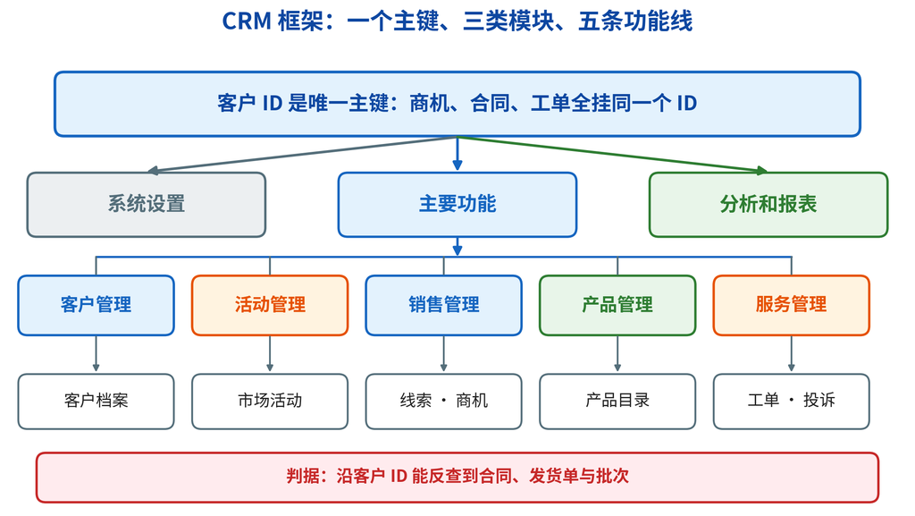

- **是什么**：主数据层（客户 ID）→ 模块带（系统设置、主要功能、分析和报表）→ 功能线（客户、活动、销售、产品、服务）→ 单据
- **为什么**：主键决定集成方式。CRM 以客户为主键，ERP 以物料、MES 以工单，三套主键要靠映射才能连上
- **怎么判断**：任取一条服务记录，能否沿客户 ID 找到合同、发货单与批次；查不回就是没集成
- 画图时要画到**单据**层（机会、报价、合同、工单），只写菜单名等于没画完

## 十二项功能：四组，各自回答一个问题

| 功能组 | 包含功能 | 回答的问题 | 判据（能否当场演示） |
| --- | --- | --- | --- |
| 档案组 | 客户信息、多渠道整合、客户细分 | 客户是谁、从哪来 | 同一客户的多渠道记录是否并成一个 ID |
| 过程组 | 销售流程记录、线索培育、工作流 | 线索怎么变订单 | 每条线索是否有阶段、负责人、下一步时间 |
| 触达组 | 营销自动化、服务与支持、移动协作 | 怎么触达与闭环 | 一次活动能否算出投入与成交 |
| 洞察组 | 数据分析、智能预测、合规与安全 | 下一步会怎样 | 字段是否最小必要、权限是否按角色 |

- 顺序就是**数据链**：先有档案，才有过程；先有过程，才谈触达与洞察
- 最容易缺的是第四组：合规与安全不是附加项，客户数据是敏感数据，采集范围要有依据
- 判据：不必十二项全会，**档案组与过程组各能演示两项**才算 CRM 在用

## 客户生命周期五阶段与跃迁判据

- 阶段不是感觉，是**门槛**：每条门槛都要写成可查、可判的条件
- 同一客户卡在两段边界时，以**主合同**所处阶段为准

| 阶段 | 客户状态 | 进入下一阶段的门槛 | 主指标 |
| --- | --- | --- | --- |
| 潜在 | 有需求、有预算，未成交 | 需求、预算、决策人、时间表齐全 | 商机转化率 |
| 新客 | 首单交付，关系刚建立 | 验收通过且完成首次回访 | 首单满意度 |
| 成长 | 开始复购或加购 | 12 个月内复购两次以上 | 复购率、客单价 |
| 稳定 | 主动推荐，价格敏感度低 | 产生转介绍或按期续约 | 留存率、NPS |
| 衰退 | 采购间隔拉长、互动变少 | 60 天无互动或间隔翻倍 | 流失率、赢回率 |

- 这是**关系**的生命周期，与第 6 讲的**产品**生命周期不是一回事，别混用同一套时钟。
- 动作按阶段配置：新客做交付体验，成长做交叉销售，衰退做挽留
- 考核要分段：只考核签约额，销售就会把客户都堆在“新客”这一段

## RFM 是什么：三个维度、八类客户、一条前提

| 类型 | R | F | M | 对应动作 |
| --- | --- | --- | --- | --- |
| 重要价值 | 高 | 高 | 高 | 专属服务、优先供货 |
| 重要发展 | 高 | 高 | 低 | 提客单价、交叉销售 |
| 重要保持 | 高 | 低 | 高 | 提高购买频次 |
| 重要挽留 | 低 | 高 | 高 | 主动回访、给挽回方案 |

- **四把切法**：价值、行业与规模、需求、行为；RFM 是价值切法的实现，综合分 $S=w_RR+w_FF+w_MM$，权重变了资源去向就变。
- **前提**：阈值先写死（经验值或分位数），否则换个人算就换一套结论
- **怎么判断**：分层结果要落到动作、预算、负责人；只出报表不配动作，等于没做

## RFM 算例：先定阈值，再分层，最后配动作

阈值：**R ≤ 60 天**为高、**F ≥ 5 次**为高、**M ≥ 3000 元**为高。

[output not shown]

- 判读顺序：先看**丁**——曾经高价值（F、M 高）、现在沉默（R 差），最该抢在流失前回访
- 判据：六个人六个动作，没有两个动作相同，说明分层真的改变了资源投放

## 五项分析工具：从看到猜到，判据在口径与误差

| 工具 | 回答什么 | 判据 |
| --- | --- | --- |
| 数据仪表板 | 现在怎么样 | 指标口径与财务、库存系统一致 |
| 统计分析 | 客户像谁 | 样本能代表整体，分层维度写清 |
| 预测分析 | 下一步会怎样 | 看误差带，不只看曲线 |
| 数据挖掘 | 谁和谁一起买 | 规则要用交易数据复核，相关不等于因果 |
| 营销智能 | 花出去值不值 | 活动 ROI 能核算到人、到渠道 |

- 五项是**成熟度阶梯**：先看清（仪表板）→ 再解释（统计）→ 才谈预测与挖掘，跳级做的都不可信
- 上报前只问一句：**口径谁定的、误差多大**——答不出的数字，再漂亮也不能用

## 销售流程五段：每段的准入与交付物

| 阶段 | 准入判据 | 关键交付物 | 卡点指标 |
| --- | --- | --- | --- |
| 线索 | 有联系人与需求描述 | 线索卡（来源、行业、需求） | 48 小时未首触 |
| 商机 | 需求、预算、决策人、时间表 | 商机单（金额、赢率、签约日） | 停留超过 30 天 |
| 报价 | 方案与成本已核算 | 报价单（版本、有效期、折扣） | 报价周期 |
| 合同 | 价格与条款谈定 | 合同（交期、付款、违约） | 审批在途天数 |
| 回款 | 发货或验收完成 | 发票、回款计划 | 逾期天数 |

- 五段之间靠“状态字段加审批”推进，不靠口头同步
- 每段都要有**退出判据**：不满足就不许进入下一段
- BANT 是商机段的四问：预算、权限、需求、时间
- 判据：任取一个商机，一分钟内说出在哪段、下一步谁做、何时做

## 销售漏斗与转化率：哪一段在漏

[figure not shown]

- 漏斗不是一张图，而是客户管理、销售管理与报表里的**状态字段**汇总出来的
- 示例：线索 2,000 → 商机 500 → 报价 200 → 合同 80 → 回款 76
- 相邻转化率 25%、40%、40%、95%，总转化率 3.8%
- 商机到报价从 40% 提到 50%，成交由 76 增到 95，增幅 25%
- 漏斗三个失真：重复计数、阶段回退、金额与单数混用
- 判据：先看哪一段的相对转化率最低，再谈投入

## 线索管理：来源、评分与分配

- 来源分三类：自有（官网、展会、老客推荐）、付费（搜索、广告）、外拓（陌拜、名单）
- 每类来源要单独记成本，否则算不出渠道的获客成本

| 评分维度 | 判据 | 分值 |
| --- | --- | --- |
| 行业匹配 | 属于目标行业 | 30 |
| 企业规模 | 营收或员工数达标 | 20 |
| 联系人角色 | 决策人或影响者 | 20 |
| 行为强度 | 下载资料、参会、询价 | 30 |

- 评分等于属性分加行为分，满分 100，80 分以上为 A 级
- 分配按行业、区域、规模路由；A 级 24 小时内首触
- 保护期：归属人 30 天不跟进，线索回收重分
- 判据：每条线索能查到来源、评分、归属人、下次跟进时间

## 商机管理与销售预测：加权管道

- 商机三要素：金额、阶段赢率、预计签约日；缺一项就不能进预测
- 加权预测：$F=\sum_{i} A_i p_i$，即各商机金额乘赢率后求和

| 商机 | 金额（万元） | 阶段赢率 | 加权金额（万元） |
| --- | --- | --- | --- |
| A | 200 | 60% | 120 |
| B | 150 | 40% | 60 |
| C | 80 | 20% | 16 |
| 合计 | 430 | — | 196 |

- 已有签约 150 万元时，本期预测为 $196+150=346$ 万元
- 阶段赢率取自历史同阶段的成交率，不取销售的个人判断
- 三个坑：赢率凭感觉、签约日永远写“下个月”、只算金额不算毛利
- 判据：每周回算预测与实际，偏差超过 20% 要复盘

## 报价与合同管理：三道闸与版本

- 报价五要素：配置、价格、交期、付款条件、有效期
- 三道闸：成本核算（毛利底线）、折扣审批、法务条款

| 闸口 | 审什么 | 不通过的后果 |
| --- | --- | --- |
| 成本核算 | 物料成本、运费、安装费 | 越卖越亏，年底才发现 |
| 折扣审批 | 折扣率、客户等级、批量 | 价格失控、渠道窜价 |
| 法务条款 | 验收标准、违约、知识产权 | 交付争议、尾款收不回 |

- 折扣分级（示例口径）：5% 以内销售经理，5%～10% 大区，10% 以上总经理
- 版本管理：每次报价留版本号与失效日，杜绝“口头价”
- 合同关键字段回写 ERP：客户、物料、数量、单价、交期、付款计划
- 判据：报价单能一键转销售订单，字段不重录

## 订单交付与服务衔接：序列号是钥匙

- 五步：订单评审 → 排产 → 发货 → 安装验收 → 服务移交
- 订单评审看三件事：信用额度、产能与交期、特殊条款

| 环节 | 主责系统 | 交接单据 |
| --- | --- | --- |
| 订单评审 | CRM 与 ERP | 销售订单、交期承诺 |
| 排产 | APS | 工单、工序时点 |
| 发货 | WMS | 出库单、序列号清单 |
| 安装验收 | 服务 | 验收单、保修起算 |
| 服务移交 | CRM | 设备档案、SLA 等级 |

- 连接键四个：客户号、合同号、物料号、序列号或批次号
- 验收单是保修起算点，也是责任边界：装完不验收，扯皮从这里开始
- 判据：客户报出序列号，能拉出合同、批次、工单、安装记录

## 客户服务流程：受理到关闭的五段

| 环节 | 关键动作 | 时限（示例） | 输出 |
| --- | --- | --- | --- |
| 受理 | 建单、分级、查历史 | 15 分钟 | 工单号 |
| 派工 | 按技能、区域、负载指派 | 30 分钟 | 派工单 |
| 处理 | 远程或到场，记录备件 | 按 SLA 分级 | 处理记录 |
| 回访 | 确认修复、问满意度 | 关闭后 2 天 | 回访记录 |
| 关闭 | 归档、沉淀知识库 | 无固定时限 | 关闭原因码 |

- 分级三档：P1 停机、P2 降级、P3 咨询；时限按档位逐级放宽
- 一次派对人靠技能矩阵：设备型号、故障类型、工程师三列对上
- 关闭原因码是改进入口：同一码反复出现，就该进 8D
- 判据：工单能反查到产品序列号、生产批次与责任工程师

## SLA 与 KPI：响应、解决与一次解决率

- SLA 三层时限：响应、到场、解决；按 P1、P2、P3 分级约定
- 三个 KPI：响应达标率、解决达标率、一次解决率

| 指标 | 口径 | 本例结果（500 张工单） |
| --- | --- | --- |
| 响应达标率 | 首响在时限内的工单 ÷ 总工单 | 94.0%（470 张） |
| 解决达标率 | 解决在时限内的工单 ÷ 总工单 | 88.0%（440 张） |
| 一次解决率 | 首次上门即解决的工单 ÷ 总工单 | 70.0%（350 张） |

- 一次解决率的口径争议：同一故障 7 天内复发，算不算未一次解决
- 分母必须写死：全部工单、有效工单、还是关闭工单，结论差很多
- 挑单风险：只接容易的工单，达标率好看，客户问题没解决
- 判据：SLA 是对客户的承诺，KPI 是对自己的约束，两者不能互代

## 呼叫中心与工单系统：全渠道一个池

- 呼叫中心四件：排队路由（ACD）、语音导航（IVR）、弹屏（CTI）、录音质检
- 全渠道汇入同一工单池：电话、微信、邮件、门户、App
- 工单五要素：单号、分类、优先级、责任人、SLA 计时器

| 组件 | 作用 | 关键指标 |
| --- | --- | --- |
| ACD | 按技能组排队分配来电 | 接通率、排队时长 |
| IVR | 语音导航与自助查询 | 自助完成率 |
| CTI | 来电弹屏客户与工单 | 客户一次识别率 |
| 知识库 | 历史解决方案检索 | 引用率、复用率 |

- 坐席排班按小时话务量算，排队模型给出满足等待目标的坐席数
- 知识库不沉淀，等于每个客户都在替企业做一次复现实验
- 判据：客户只报一次问题，不该被要求再打另一个电话

## 客户满意度与 NPS：三个指标一个坑

- 三个指标：CSAT 单次满意度、NPS 关系推荐度、CES 费力程度
- NPS 的算法：推荐者（9～10 分）比例减贬损者（0～6 分）比例，中性者不计

$$NPS=\frac{N_p-N_d}{N}\times 100\%$$

| 指标 | 问法 | 本例结果（200 份） |
| --- | --- | --- |
| NPS | 你有多大可能推荐我们？ | 推荐者 45%、贬损者 20%，得 25 |
| CSAT | 本次服务满意吗？ | 4～5 分占 75% |
| CES | 解决问题费不费力？ | 取 1～7 分均值 |

- 一个坑：NPS 与 CSAT 混用——一个问关系，一个问单次，不可互换
- 另外两个坑：只取样满意客户、把 NPS 挂到个人绩效上
- 判据：满意度要能追到具体环节与责任人，否则无法改进

## 客户流失预警与挽留：先算期望收益

- 四类信号：采购间隔拉长、询价减少、投诉增多、关键联系人离职
- 预警分档：各信号加权成风险分，按分位切成高、中、低三档
- 挽留阶梯：客服回访 → 客户经理 → 技术方案 → 高层拜访 → 让价

| 客户 | 年毛利（万元） | 期望保住毛利（万元） | 期望净收益（万元） |
| --- | --- | --- | --- |
| 甲 | 24 | 4.8 | 3.3 |
| 乙 | 8 | 1.44 | 0.64 |

- 算法：年毛利 × 流失概率 × 挽留成功率，再减挽留成本（甲 1.5、乙 0.8 万元）
- 甲的流失概率 40%、挽留成功率 50%；乙为 60% 与 30%
- 判据：期望净收益为正且客户仍有价值才投入；战略客户另算
- 让价放最后，因为让价会训练客户等降价

## 营销自动化与精准营销：从群发到滴灌

- 自动化四件：线索培育、触发式触达、评分路由、效果归因
- 精准三步：分群 → 内容 → 节奏，节奏里要含频率上限与退订入口
- 触发式场景：注册未下单、报价未回签、合同到期前 90 天
- ROI 算例：触达 5,000 家，转化 3% 得 150 单

| 口径 | 计算 | 结果 |
| --- | --- | --- |
| 成交额 | 150 单 × 2,400 元 | 36.0 万元 |
| 毛利 | 36.0 万元 × 30% | 10.8 万元 |
| ROI | 投入 8.0 万元 | $ROI=\dfrac{10.8-8.0}{8.0}=35\%$ |

- 归因口径：首触、末触、线性分摊，换一种算法结论就变
- 合规红线：未经同意不得群发，推送须提供便捷拒绝方式
- 判据：每次活动有目标人群、预算、归因口径、复盘结论

## 渠道与经销商管理：DMS 与双口径库存

- 渠道三层：厂商 → 总代或区域代理 → 经销商与集成商
- DMS 五模块：项目报备、价格返利、订单库存、售后服务、培训认证

| 模块 | 管什么 | 常见失控点 |
| --- | --- | --- |
| 项目报备 | 谁先报、保护期、冲突裁决 | 内部抢单、报备占坑 |
| 价格返利 | 阶梯价、返利核算与兑付 | 返利算不清、年底扯皮 |
| 订单库存 | 出货与终端销量 | 只看压货、渠道库存失真 |
| 售后服务 | 保修归属、备件供应 | 厂商与渠道互相推 |

- 报备规则要写死：先报先得、保护期 90 天（示例）、逾期释放
- 双口径：sell-in 是厂商出货，sell-out 才是终端真实需求
- 窜货识别：序列号、区域码、异常价格，三件一起看
- 判据：渠道库存与终端销量对得上，返利才算得清

## 移动 CRM 与社交 CRM：现场与舆论

- 移动四场景：拜访签到、现场报价、扫码查档、离线填单

| 场景 | 移动端做什么 | 后台得到什么 | 风险 |
| --- | --- | --- | --- |
| 拜访签到 | 定位、拍照、填纪要 | 拜访真实性与频次 | 定位即监控 |
| 现场报价 | 查价、选配、出报价单 | 报价周期与折扣 | 离线价格过期 |
| 扫码查档 | 扫序列号看档案与工单 | 服务历史完整 | 标签污损扫不出 |
| 离线填单 | 断网先存本地 | 回传后补全记录 | 冲突合并出错 |

- 社交 CRM 三件事：社交聆听、社交客服（私信转工单）、口碑运营
- 社交数据的坑：刷量水军、平台接口受限、样本不代表整体
- 移动端铁律：一次录入不超过 5 个字段，否则现场一定糊弄
- 判据：外勤数据是顺便采集，还是专门回来补录

## 客户洞察：360° 视图怎么建

- 四类数据：交易、服务、行为、外部（工商与舆情）
- 一个客户一个 ID：子公司、联系人、地址做成层级，不做成多个客户

| 步骤 | 做什么 | 判据 |
| --- | --- | --- |
| 归集 | 打通交易、服务、行为、外部四源 | 数据覆盖率 |
| 识别 | 手机号、邮箱、域名做实体匹配 | 重复率 |
| 标签 | 事实标签、模型标签、规则标签 | 标签可用率 |
| 应用 | 分层、预警、推荐、定价 | 业务使用率 |

- 标签分三类：事实（行业、规模）、模型（RFM、流失概率）、规则（大客户）
- 360° 不是字段多，而是口径一致、来源可追溯、更新及时
- 判据：这个视图能否回答“客户值多少、下一步该做什么”

## CRM 与智能制造：定制入口与服务出口

- 定制链：配置器选型 → 报价与 BOM → 订单 → 变型设计 → APS 排产 → MES 生产
- 服务型制造：从卖设备到卖可用性，收入由一次性转为经常性

| 方向 | CRM 输出什么 | 谁接 |
| --- | --- | --- |
| 需求洞察 | 客户画像、偏好、需求预测 | PLM、ERP |
| 定制配置 | 选型、变型、报价 BOM | PLM、ERP |
| 产销协同 | 订单与预测 | APS、ERP |
| 服务闭环 | 工单、故障码、备件消耗 | MES、质量系统 |

- 设备联网后运行数据回流服务：预测性维护、备件预测、产品改进
- 定制化三个前提：配置器可维护、BOM 可配置、报价能算准成本
- 判据：客户数据是否流进计划与生产；服务收入能否单独核算
- 一句：CRM 在智能制造里同时是需求入口与服务出口

## CRM 与 ERP／MES 的集成：主数据与单据

- 主数据分工：客户与商机归 CRM，物料与财务归 ERP，批次与工序归 MES
- 单据流：报价 → 订单 → 发货 → 开票 → 回款；服务单 → 备件出库 → 工时结算

| 数据对象 | 主责系统 | 流向 | 冲突处理 |
| --- | --- | --- | --- |
| 客户 | CRM | 推给 ERP，回写信用 | 一客多码，定期合并 |
| 物料与价格 | ERP | 单向供给 CRM | 价格版本带生效日 |
| 库存与交期 | ERP 与 WMS | 查询接口 | 缓存过期要提示 |
| 序列号与批次 | MES | 服务单反查 | 号段唯一，禁止手改 |

- 三种集成方式：接口（API）、中间表或文件、统一平台
- 服务单反查链：序列号 → 工单 → 批次 → 供应商 → 8D
- 判据：同一份数据两边各存一份时，谁改、何时同步，必须写死

## CRM 选型与实施：评分表与四个失败原因

- 选型四问：业务匹配、集成能力、可配置性、总拥有成本
- 加权评分（示例权重）：功能 40%、集成 25%、服务 20%、成本 15%

| 维度 | 权重 | 方案 A | 方案 B |
| --- | --- | --- | --- |
| 功能 | 40% | 85 | 70 |
| 集成 | 25% | 70 | 90 |
| 服务 | 20% | 80 | 75 |
| 成本 | 15% | 60 | 85 |
| 加权合计 | — | 76.5 | 78.25 |

- 结论：功能最强的 A 输给集成与服务更好的 B——加权口径决定结论
- 四个失败原因：口径不统一、主数据脏、业务不参与、上线即停更
- 判据：上线成功的标志是销售愿意用，不是系统能登录

## 数据隐私与合规：字段设计就是合规

- CRM 是个人信息最密集的系统：姓名、电话、地址、轨迹、通话记录
- 五条硬约束：
  - 最小必要：限于实现目的的最小范围，不得过度收集（第 6 条）
  - 告知：处理前告知目的、方式、种类、保存期限（第 17 条）
  - 单独同意：敏感个人信息含行踪轨迹（第 28、29 条）
  - 删除：目的已实现或撤回同意后应删除（第 47 条）
  - 罚则：情节严重可按上一年度营业额 5% 以下罚款（第 66 条）
- 字段设计：能不采就不采；手机号脱敏展示；导出留痕与审批
- 推送营销要提供不针对个人特征的选项或便捷拒绝方式（第 24 条）
- 员工外勤定位也属个人信息：告知、限工作时间、限用途
- 判据：客户问“你存了我什么、给谁看过”，三天内能否答出

## 案例：某装备企业从卖设备到卖服务

- 情景（教学假设）：年销 200 台×120 万元＝2.4 亿元；装机 1,500 台，服务收入 4,500 万元（单台 3 万元／年）

| 口径 | 设备 | 服务 | 合计 |
| --- | --- | --- | --- |
| 收入（万元） | 24,000 | 4,500 | 28,500 |
| 毛利率 | 18% | 45% | — |
| 毛利（万元） | 4,320 | 2,025 | 6,345 |
| 收入占比 | 84.2% | 15.8% | 100% |
| 毛利占比 | 68.1% | 31.9% | 100% |

- 服务收入只占 15.8%，却贡献 31.9% 的毛利——这是“卖服务”的动机
- 三个动作：设备档案（序列号）→ 服务合同（SLA 分级）→ 工单与备件联动
- 要盯的口径：续约率、单台服务收入、非计划停机时长，均须实测不预设
- 判据：服务收入与设备收入分开核算，才看得出服务是否真赚钱

## CRM 复习要点：五背三算两画

- 五个必背：定义与三目标、生命周期五阶段、销售五段、服务五段、RFM 三维
- 三个必会算：$CLV/CAC$、漏斗转化率、$NPS$
- 两个必会画：销售漏斗、服务闭环
- 三个易错：转化率的分母、一次解决率的口径、NPS 与 CSAT 混用

| 题型 | 问法 | 答题要点 |
| --- | --- | --- |
| 计算 | 给漏斗或工单数据 | 先写分母与口径，再算 |
| 判断 | 这属于哪个阶段 | 用门槛条件逐条对照 |
| 设计 | 设计一张工单或字段 | 谁用、何时用、缺了会怎样 |
| 合规 | 这些字段能不能采 | 目的、范围、同意方式 |

- 一条主线：客户资产等于客户数乘单客贡献再乘关系长度

## 本部分小结：客户资产的三句话

- 第一句：CRM 管的是**客户资产**（数量乘单客贡献再乘关系长度），不是通讯录
- 第二句：销售漏斗与服务闭环是骨架，转化率、SLA、一次解决率、NPS 是判据
- 第三句：数据合规是前提；与 ERP、MES 打通才产生智能制造价值
- 一条链路：客户需求 → 订单（CRM）→ 物料与能力（ERP）→ 工序时点（APS）→ 生产（MES）
- 一个反例：只存客户档案、不进计划的 CRM，本质是一本昂贵的通讯录
- 下一步：订单进来后，料在哪、先做谁——仓储与排程
- 带走一个判据：任何 CRM 页面，都要能回答“这个客户值多少、下一步做什么”

# 第二部分 · 第 2 内容块：WMS 与 APS

- WMS：从收货到出库的每一次移动都要有记录，盘点是账实相符的最后一道闸
- WMS 的七大核心功能、五张核心报表；库存周转、EOQ 与安全库存两个算例
- APS：四类约束、排程建模的三要素、五代算法与四算法算例
- APS 与 ERP／MES 的集成：数据从哪来、指令到哪去、插单多久重排

## WMS 的定义与目标：账实相符、高效作业

- **定义**：优化仓储与物流作业的综合系统，覆盖入库、存储、拣选、打包、出库
- 一句话：它不只是工具，更是政策与流程——上架、波次、拣选、补货、盘点
- 目标一**账实相符**：有什么、在哪里、有多少、什么状态，四项都对得上
- 目标二**高效作业**：同样的人、地、设备，做出更多订单行、更短履约周期
- 边界：库门以内归 WMS；库外运输多由 TMS 承担，也有企业并进 WMS
- 五项驱动力：实时库存、全程可视、快速交付、精细退货、系统集成
- 线边仓的归属要事先写进方案：常见做法是中心仓归 WMS、线边仓归 MES
- 常用 KPI：订单处理时间、拣货准确率、库存周转率，前两个看作业、后一个看资金
- 判据：任取一个库位，系统数与实物数一致；任取一箱货，能追到批次与去向

## WMS 的四层框架：单据、作业域、控制层、设备层

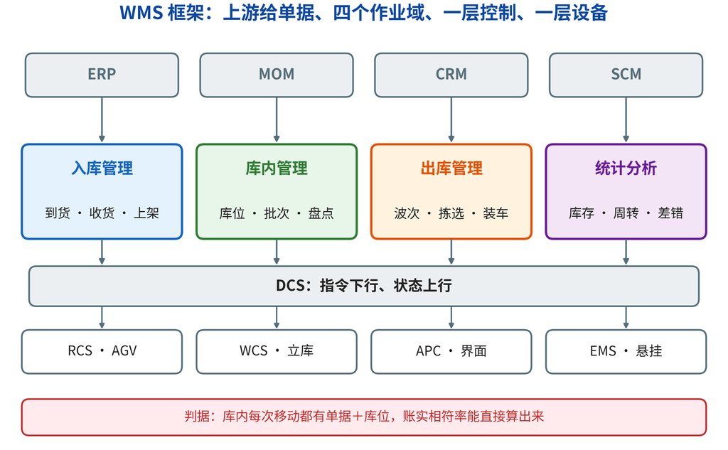

- **是什么**：上游四系统给单据，中间四个作业域干活，往下经 DCS 控制设备，状态再回传上来
- **为什么**：WMS 的边界在**库门**——库内一切移动归它管，库外的运输归 TMS；边界不清，账实永远对不上
- **怎么判断**：四个作业域是否各有单据与报表；设备层是否只做执行、不做决策
- 与 MES 的分界：线边仓通常归 MES，中心仓与成品仓归 WMS，交接靠发料单与批次

## 作业五段：每段的判定标准都写在表里

| 环节 | 关键动作 | 常见策略 | 判定标准 |
| --- | --- | --- | --- |
| 收货入库 | 到货验收、贴标、系统登记 | 预约、月台分配 | 收货准确率 100% |
| 上架 | 分配库位、搬运、扫码确认 | 就近、分区、混放限制 | 库位与系统一致 |
| 存储 | 库位、批次与效期、盘点 | FIFO／FEFO、ABC | 账实相符率 |
| 拣选 | 生成拣货任务、分拣 | 波次、摘果／播种 | 拣货准确率与效率 |
| 复核出库 | 复核、称重、打包、装车 | 复核策略、发运策略 | 差错率、准时发运率 |

- 硬件相同、**策略不同，效率差一倍**——这是 WMS 花钱的地方，不是买扫码枪
- 智能制造里还要加两条联动：对 MES 做**齐套发料**、对 APS 报**缺料与交期**
- 判据：任取一单，能否说出它现在在哪一段、下一步谁做、卡在哪个策略上

## 库位管理与存储策略：固定、随机、ABC

- 库位编码五级：**库区—巷道—货架—层—位**，一位一码，扫码即定位
- 一个 SKU 允许放多处，但每多一处，查找与盘点成本就多一分
- 固定库位：一物一位，好找好管，代价是忙季爆仓、淡季空置
- 随机库位：见缝插针，空间利用率高，代价是路径变长、离不开系统指路
- ABC 分区：按出货量把库位分三档，A 类贴近出货口，C 类放远端与高层
- 距离算例：A 类占 70% 订单行，每行少走 25 m，平均省 17.5 m/行

| 策略 | 分配规则 | 优点 | 代价 |
| --- | --- | --- | --- |
| 固定 | 一物一位、专区专放 | 好找、易盘点 | 空间利用率低 |
| 随机 | 有空位就放 | 利用率高 | 路径长、靠系统 |
| ABC | 按周转率分区 | 省行走时间 | 需定期重排 |

- 判据：库位利用率与拣货行走距离/行要一起看，单看一个都会走偏

## 仓库布局与动线：面积、通道与作业面

> 上一页定了“一个 SKU 放几个位”，这一页回答这些位在仓库里怎么摆、人要走多少路。
- 布局按三块分摊面积：**存储区**、通道与作业面、收发货月台；先定块，再排货架，最后编库位
- 算例：本讲盲盘页的 5,000 个库位，每库位按 1.2 m × 1.0 m 计，存储区 $5{,}000\times1.2=6{,}000$ m²
- 通道按存储区的 0.8 倍配：$6{,}000\times0.8=4{,}800$ m²；总面积 $6{,}000+4{,}800=10{,}800$ m²，约 104 m × 104 m
- 动线三型：I 型收发同侧、L 型邻边、U 型三面；同一条巷道只走一次，是布局的硬约束
- 行走算例：日 2,000 订单行、每行 25 m，动线优化压 20%，$2{,}000\times25\times20\%=10{,}000$ m＝10 km/天
- 按 4 km/h 的拣货行走速度折算，$10\div4=2.5$ h/天——布局省下的就是两个半工时
- 货架选型四问：层高、承重、存取方式（人工／AS-RS）、消防分区；层高定错，立体库的钱就白花
- 判据：单位面积吞吐量与拣货行走距离/行同时看，一个升一个降才算布局改对了

**结论：布局不是画图，是把面积换成库容与行走时间的取舍。**

## 收货与质检收货：把错误挡在库门外

- 收货三查：**单据**（与到货通知一致）、**数量**、**质量**（外观、证书、抽检）
- 两条路径：免检直接上架；需检进待检区，状态锁为“待检”
- 质检四步：抽样→判定→状态转换（合格／不合格／让步接收）→归档
- 批次与效期一次录对，录错一次整批失去追溯
- 待检库存不得当可用库存投料或发货，最易被绕过

| 异常 | 表现 | 处理 |
| --- | --- | --- |
| 短装 | 实收少于订单 | 按实收入库，通知采购补货 |
| 溢装 | 实收多于订单 | 征求供方意见，超收部分单独挂账 |
| 错料 | 型号或批次不符 | 拒收或让步，隔离并标识 |
| 破损 | 外观或包装损伤 | 拍照留证，索赔或退换 |

- 判据：收货时每个“差不多”，都会在盘点时变成差异

## 上架策略：就近、周转率与混放规则

- 上架要同时满足三个约束：**有空位**、**放得下**（尺寸、承重、温区）、**放得合理**（周转、关联、混放）
- 就近上架：找离收货口最近的空位，上架快；代价是黄金库位被慢销品长期占用
- 周转率优先：快销品靠近出货口，慢销品放远端与高层，让“走得多的少走路”
- 关联上架：常在同一订单里一起拣的物料放相邻，减少拣货折返
- 混放规则：同库位不混批次、不混效期；重不压轻；危化与食品隔离；待检与合格分区
- 优先级：先过“必须”（尺寸、温区、混放），再优化“最好”（距离、关联）
- 一个反例：把周转率最高的货放在收货口旁，上架省了，拣货却要多走一大截
- 判据：上架看每小时上架行数，布局看拣货行走距离，两个指标一起变好才算策略对

## 拣货策略：摘果、播种、分区与波次

| 策略 | 做法 | 适用 | 代价 |
| --- | --- | --- | --- |
| 摘果 | 一人一单，边走边拣齐 | 大件、少品种、单据少 | 单多时重复走货架 |
| 播种 | 先汇总拣货，再到分播墙按单投放 | 小件、多单、电商 | 需分播场地与二次复核 |
| 分区 | 按库区拆分，各区并行拣、最后合单 | 大仓、品类差异大 | 合单与交接复杂 |
| 波次 | 按发车时间、线路、承运商合并订单 | 有固定发车时刻 | 批次切分不当会压单 |

- 播种的关键是“**先集后分**”：拣货只走一遍货架，行走被摊到几十张单上
- 数量感：100 张单、每单 3 行共 300 行；摘果走 100 遍货架，播种走 1 遍、再投 100 个格口
- 摘果责任最清，一单一人，出错查得到人；播种必须配二次复核才敢发
- 波次不是越勤越好：切太细批次多，切太粗订单压在仓里等发车
- 选型三问：订单行多少、SKU 集中在哪、时效窗口多长
- 判据：拣货准确率与每小时拣货行数同时看，只快不准等于没快

## 复核与装车发运：出库前最后一道闸门

- 复核三对：**品项对**（扫 SKU）、**数量对**（点数或称重）、**包装对**（标签、面单、随货文件）
- 两种手段：人工逐单复核；称重比对——系统给标准重量区间，超差即报警
- 装车三件事：按卸货顺序装（后卸先装）、算装载率、排月台与发车时刻
- 单据链：出库单 → 装箱单 → 承运单 → 签收回单，四张单缺一张，责任就断
- 三类异常：错发（追回或换发）、少发（补发并查拣货记录）、破损（换货加理赔）
- 指标：准时发运率、错发率、装载率、回单及时率
- 一个算账思路：错发一次的成本是一次往返运费加客户信任，远比复核工时贵
- 判据：复核不是“快点发”，而是“发出去就不用回来”

## 盲盘与循环盘点：把账实相符做在日常

- 盲盘：盘点单不显示账面数，只报实物（防“照着账面填”）；有差异的条目换人复盘
- 循环盘点：按 ABC 定频次，A 类月盘、B 类季盘、C 类年盘，不停业
- 频次算例：5,000 个库位（A 1,000、B 1,500、C 2,500），每月盘 1,708 个，约 78 个/工作日
- 差异四类原因：录错（收发错）、放错（库位错）、丢损、单位换算

| 差异类型 | 典型表现 | 对策 |
| --- | --- | --- |
| 录错 | 数量与单据不符 | 复核收发单据与扫描记录 |
| 放错 | 库位有货、系统无账 | 查最近移库与上架记录 |
| 丢损 | 实物少于账面 | 查监控、封箱、追责 |
| 换算 | 箱与件不一致 | 统一计量单位与换算率 |

- 调账要审批、要写原因，不能“月月调平了事”
- 判据：同一库位连续三个月都差异，是流程问题，不是人的问题

## 库存策略：EOQ 与再订货点

- 年总成本＝订货成本＋持有成本：$TC=\dfrac{D}{Q}S+\dfrac{Q}{2}H$
- 对 $Q$ 求导得经济订货批量 $Q^{*}=\sqrt{\dfrac{2DS}{H}}$，最优处两笔成本相等
- 敏感性：$Q^{*}$ 与 $\sqrt{D}$ 同阶——需求翻倍，批量只增 $\sqrt{2}\approx1.41$ 倍
- 算例：年需求 9,000 件、每次订货 200 元、每件年持有 4 元，$Q^{*}=949$ 件
- 需求升到 18,000 件，$Q^{*}=1{,}342$ 件，只增 41%，不是翻倍
- 再订货点 $\text{ROP}=\bar d\,L+\text{SS}$，提前期含订货、运输、检验、上架四段
- 定量订货盯“剩多少”，定期订货盯“到没到日子”；前者适合 A 类，后者适合 C 类
- 判据：EOQ 是成本最优，不是交期最优；缺货代价高时要用服务水平反推

## 安全库存与服务水平：三个杠杆

- 需求独立、提前期固定时：$\text{SS}=z\,\sigma_d\sqrt{L}$
- 三个杠杆：需求波动 $\sigma_d$、提前期 $L$、服务水平对应的 $z$
- $z$ 值查表：90% 取 1.28、95% 取 1.65、99% 取 2.33；服务水平是“周期内不缺货的概率”
- 算例：$\sigma_d=40$ 件/天、$L=5$ 天、95% 服务，$\text{SS}=1.65\times40\times\sqrt{5}\approx148$ 件
- 提前期压到 3 天，$\text{SS}\approx114$ 件，降 23%——缩提前期比加库存便宜
- 提前期也波动时：$\text{SS}=z\sqrt{L\sigma_d^{2}+\bar d^{2}\sigma_L^{2}}$
- 聚合效应：4 个相同需求点合并，$\sigma$ 只增 2 倍，总安全库存可降一半
- 判据：先降波动、缩提前期，再谈提高服务水平；反过来做是用钱买不确定

## 库存周转率与呆滞料：慢的才是贵的

- 周转率＝年销货成本÷平均库存；周转天数＝365÷周转率
- 分母要用平均库存（期初加期末除以二），用期末数会让年底冲量“好看”
- 分段看：原材料、在制、成品各有周转率，谁的周转慢就治谁，不要只看总数
- 呆滞三档：90 天无动碰（关注）、180 天（预警）、365 天（处置并计提跌价）
- 成因五条：设计变更、订单取消、超量采购、最小起订量、预测偏差；处置五条：退供方、调拨、改制代用、降价清仓、报废
- 算例：库存 600 万元、呆滞 45 万元（7.5%），按 50% 计提，减值 22.5 万元

| 库龄档 | 判定口径 | 动作 |
| --- | --- | --- |
| 90 天 | 无收发、无动碰 | 列入关注清单 |
| 180 天 | 连续无需求 | 预警、找替代订单 |
| 365 天 | 一年无动碰 | 处置并计提跌价 |

- 周转算例：销货成本 3,600 万元、平均库存 600 万元→周转 6 次、60.8 天；提到 8 次为 45.6 天，压 15 天可释放 $3600\times15/365\approx147.9$ 万元。
- 判据：周转率上升也可能是缺货换来的，要同时看履约率

## 条码、RFID、AGV：自动化仓储的三层

- 条码：一维码管 SKU，二维码带批次、效期、序列号；便宜、要视线、要人扫
- RFID：非接触、可批量读、可读写，适合托盘与周转箱；金属与液体干扰、单价高
- 第一层存：AS／RS 立体库，堆垛机上下，向高度要空间
- 第二层搬：AGV／AMR 替代人工搬运，路径可改，不用铺轨道
- 第三层拣：货到人工作站，人不动、货到面前，省掉的正是行走时间
- 选型看四个数：SKU 数、日订单行、单位面积储量、人工与土地成本
- 投资逻辑：省人、省地、省错；不是“看起来先进”
- 判据：上了自动化之后，账实相符率与差错率是不是真的改善了

## WMS 与 ERP／MES 的集成：账与物的分工

- 一句话分工：**ERP 记账，WMS 记物**——ERP 管有多少、值多少钱，WMS 管在哪里、什么状态
- 主数据从 ERP 来：物料编码、计量单位、供应商、批次规则，WMS 不另建一套
- 收货与发货：ERP 采购／销售订单 → WMS 预约、收货或出库 → WMS 回写入库凭证、实发数量与批号
- 与 MES：MES 按工单要齐套发料，WMS 按工单拣配；线边仓归属事先定
- 三个坑：双账本、单位不一致（箱／件／千克）、批次规则不一致

| 系统 | 管什么 | 关键接口 |
| --- | --- | --- |
| ERP | 账、金额、采购与销售订单 | 主数据、出入库凭证 |
| MES | 工单执行、报工、质量 | 齐套发料、退料、线边库存 |
| TMS | 运输与承运 | 发运单、回单 |
| APS | 排程与交期 | 齐套状态、缺料预警 |

- 判据：任一笔出入库，ERP 凭证与 WMS 作业单能对上号

## WMS 的数据与报表：从记录到决策

- 四类数据：主数据（物料、库位、客户）、事务（收发存移盘）、状态（待检）、绩效（工时）
- 五张报表：库存日报、库位利用率、收发存明细、呆滞清单、作业绩效
- 报表三问：给谁看、支持什么决策、对应哪个可调参数
- 数据质量四要：及时、准确、完整、一致
- 报表要能下钻：从“有多少”点到“哪一批、哪个库位”

| 报表 | 回答什么问题 | 对应动作 |
| --- | --- | --- |
| 库存日报 | 有什么、有多少、放多久 | 补货、调拨 |
| 库位利用率 | 空间够不够、哪里堵 | 重排库位、扩区 |
| 收发存明细 | 每一笔对不对 | 对账、查差异 |
| 呆滞清单 | 哪些货不动 | 清仓、退供方 |

- 判据：看完报表不知道该调哪个参数，就白做了

## 七大功能、六项效益：验收只看右列数字

- 七大功能：货物管理、作业管理、布局优化、库存管理、数据分析、运输管理、系统集成
- 一句话：WMS 让库存“**看得见、算得清、动得快**”——看不见的是账，算不清的是钱，动不快的是单

| 效益 | 具体表现 | 可量化指标 |
| --- | --- | --- |
| 提高效率 | 任务自动分配与路径优化 | 人均拣货行数/小时 |
| 数据准确 | 条码扫描，每一步可追溯 | 账实相符率 |
| 精准控库存 | 避免积压与过期 | 库存周转率、呆滞率 |
| 提升满意度 | 实时跟踪、交付预估 | 准时交付率 |
| 优化资源 | 布局与人员调配 | 单位面积吞吐量 |
| 保障资产 | 全天候监控与报警 | 货损率 |

- 判据：六项效益里至少三项有**基线值**，否则项目结项时无法验收

## APS 的定义与目标：有限产能怎么算

- **定义**：APS 整合算法、数学模型与算力，把订单排成工序级的可执行计划
- 分水岭：MRP 假设产能无限、只算物料；APS 同时算物料与能力
- 三个目标：均衡资源负荷、给出瓶颈阶段的最优排程、快速响应需求变化

| 维度 | MRP | APS |
| --- | --- | --- |
| 产能假设 | 无限 | 有限 |
| 计划粒度 | 物料与工单 | 工序、设备、时刻 |
| 主要输出 | 采购与生产建议 | 排程、交期承诺、负荷图 |

- 输入六项：订单与预测、工艺路线、标准工时、设备与日历、物料齐套、订单优先级
- 闭环：计划 → 执行 → 监控 → 改进，排完不算完，要看执行偏差再修
- 一句话记法：MRP 算“要什么”，APS 算“做不做得出来、什么时候做得出”
- 判据：设备不撞车、物料不断线、交期算得准——三条都过才算一份排程

## APS 五步：先承诺、再计划、后执行

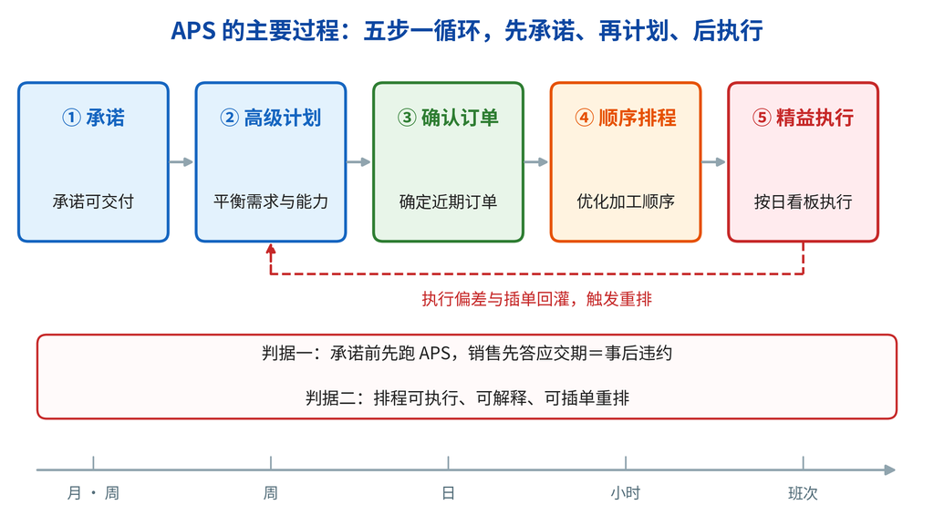

- 五步各自只回答一个问题：能不能承诺 → 未来怎么排 → 近期下哪些单 → 先做谁 → 今天做完什么
- 时间粒度逐级变细：月／周 → 周 → 日 → 小时 → 班次；混着做，两头都不准
- 执行偏差与插单**回灌**到计划，触发重排，不必等日结
- 判据：销售承诺交期前是否先跑过 APS；插单后能否在 10 分钟内给出新交期并下发 MES

## 排程建模三要素：变量、目标、约束

- **决策变量**：工序 $i$ 在设备 $j$ 上加工取 1 否则取 0；开工 $s_i$、完工 $C_i$
- **目标**：最小总逾期 $\sum T_i$、最小最大完工 $C_{\max}$、最少换型、负荷均衡（可加权成多目标）
- **约束**：工艺顺序、设备不重叠、人员与工装可用、物料齐套、班次日历

| 规模 | 组合数 | 含义 |
| --- | --- | --- |
| 5 个作业排序 | $5!=120$ | 可枚举 |
| 10 个作业排序 | $10!=3{,}628{,}800$ | 需规则或启发式 |
| 100 工单 × 10 工序 | 无法枚举 | 只能求满意解 |

- 三种建模模式：仿真、约束理论（瓶颈双向计划、非关键倒排）、数学规划（线性规划、遗传、退火）
- 判据同上：**可执行、可解释、可调整**——满足不了这三条，模型再漂亮也上不了车间

## 约束从哪来：设备、工装、人员、物料

| 约束 | 典型数据 | 排程影响 | 松弛手段 |
| --- | --- | --- | --- |
| 设备 | 台数、精度、维保计划 | 决定可选设备集 | 加班、替代机 |
| 工装 | 模具套数、寿命、共用关系 | 决定并行度 | 备模、外协 |
| 人员 | 技能矩阵、班次、资质 | 决定开班与配人 | 借调、培训 |
| 物料 | 齐套、到料日、批次 | 决定最早开工时间 | 催料、替代料 |

- 四类基本约束：设备、工装、人员、物料；每类都要落到“数据加松弛”两件事上
- 只有数据没有松弛，模型会报无解；只有松弛没有数据，排出来是空话
- 交期不是资源，却是硬边界：把订单交期倒推成每道工序的最晚完工时间
- 工装约束常被漏掉：模具寿命到了要修，修模时间同样占产能
- 物料约束的关键不是“有没有”，而是“什么时候到”——在途与齐套要分开看
- 判据：排出来的计划，四类约束逐条能验证；有一条查不到数据，计划就靠不住

## APS 与 ERP／MES 的分工：三层计划颗粒度

- 三层：ERP 主计划（月／周），APS 排程（日／班），MES 执行（实时）
- ERP 答“接不接这单”，APS 答“先做哪道”，MES 答“现在做到哪”

| 层级 | 时间粒度 | 主要输出 | 系统 |
| --- | --- | --- | --- |
| 主计划 | 月、周 | 生产计划、粗能力平衡 | ERP |
| 排程 | 日、班、时刻 | 工序顺序、开工完工时间 | APS |
| 执行 | 实时 | 工单状态、报工、异常 | MES |

- 冻结期：近端只许微调、中段可改量、远端可改期，护住已备料已上机的作业
- 变更权：ERP 改订单、APS 改顺序、MES 改报工；可执行性以 APS 为准，结果回写 ERP
- 越级改就“计划打架”：谁都能改计划，等于没人负责；结果不回写，三套口径必然分叉
- 判据：同一工单三处开工时间对得上；对不上按“报工→重排→订单变更”倒查

## 接口五个方向：事件触发才谈得上重排

- 上游 **ERP** 给订单、预测、库存、BOM、工艺路线与日历；APS 回写计划订单、交期承诺与负荷
- 下游 **MES** 收排程结果（工单顺序、开完工时间、换型计划），回传实际进度与设备异常

| 方向 | 主要数据 | 触发／时点 |
| --- | --- | --- |
| ERP → APS | 订单、预测、库存、BOM、工艺、日历 | 日启动、订单变更 |
| APS → ERP | 计划订单、可承诺交期、负荷 | 排程发布 |
| APS → MES | 工单顺序、开完工时间、换型计划 | 排程发布 |
| MES → APS | 实际进度、设备故障、报废返工 | 事件或班次 |
| WMS → APS | 齐套状态、缺料 | 发料、库存变更 |

- 冲突处理：以 APS 的**可执行排程**为准，并回写 ERP，避免口径再次分叉
- 判据：插单后 10 分钟内看到新交期；排程变更能自动下发 MES（不是靠微信通知）

## 五代算法：复杂不一定更好

| 代际 | 算法基础 | 特点 | 局限 |
| --- | --- | --- | --- |
| 第一代 | 约束理论（TOC）有限产能 | 识别瓶颈，自动生成主计划 | 依赖瓶颈识别准确性 |
| 第二代 | 规则、线性规划、启发式、专家系统 | 快速给出可行解 | 难保证全局最优 |
| 第三代 | 遗传、退火、神经网络、禁忌搜索 | 近似最优，适合复杂组合 | 参数敏感、可解释性差 |
| 第四代 | 智能算法融合＋动态调整 | 应对插单与异常 | 实时性与稳定性难兼顾 |
| 第五代 | 深度运筹（图学习＋异构张量） | 面向小批量多品种 | 数据与算力要求高 |

- 选型原则：先看**约束与目标**，再选算法；不是越新越好
- 判据：同一批作业，用新算法排出的总逾期是否真的更小——下一页用算例验证

## 四个算法算同一组作业：最简单的总逾期最少

五个作业的加工天数与交货期：A（5 天，第 6 天）、B（10 天，第 20 天）、C（4 天，第 5 天）、D（8 天，第 22 天）、E（6 天，第 8 天）。评价标准：总逾期。

| 算法 | 排序 | 完成顺序与逾期（天） | 总逾期 |
| --- | --- | --- | --- |
| 最短工期 | C→A→E→D→B | 0、3、7、1、13 | **24 天** |
| 最早交货期 | C→A→E→B→D | 0、3、7、5、11 | 26 天 |
| 交货期临近 | C→A→E→B→D | 0、3、7、5、11 | 26 天 |
| 最小关键比 | A→C→E→B→D | 0、4、7、5、11 | 27 天 |

- 关键比 $\text{CR}=\dfrac{\text{交货期}-\text{当前日期}}{\text{加工天数}}$，越小越紧急；起点 CR：A 1.20、C 1.25、E 1.33、B 2.00、D 2.75
- 结论：**最简单的“最短工期”总逾期反而最少**；判据是结果，不是算法的先进程度

## 甘特图与派工：把排程变成现场指令

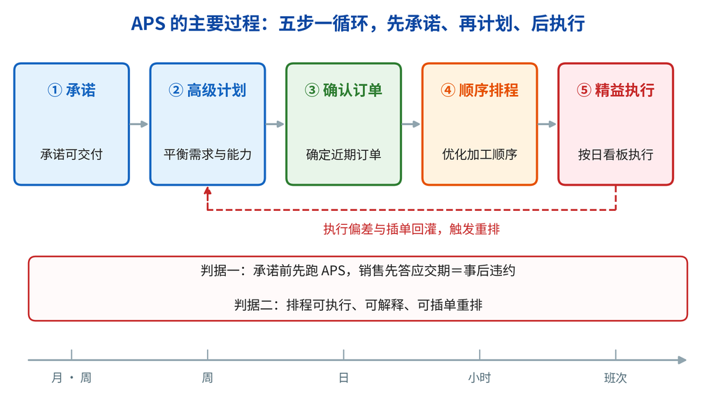

- 流程走到第 4 步“顺序排程”产出甘特图，走到第 5 步“精益执行”产出派工单
- 甘特图：横轴时间、纵轴资源、色块是工序；看撞车、空转、逾期、换型
- 派工单：工序号、开完工时间、物料齐套与图纸程序；只认最新版，版本号印在图面
- 甘特图会骗人：计划块排得满不代表做得出，要看缓冲与换型时间留没留
- 判据：甘特图上每一块，现场都能找到对应的一张派工单

## 插单与重排：动态调度的三条路

- 插单四种处理：插到队首（急单）、插进空档（填谷）、外协、拒单并重谈交期
- 重排三条路：**全重排**（全局最优、动荡大）、**局部重排**（只动受影响工序）、**滚动重排**（按班次推进）
- 动荡成本要算清：已备料、已上机、已承诺——改一张单，牵连几张单
- 冻结期加例外审批：冻结区内的插单要生产经理签字，责任才落得下去
- 指标：插单响应时间、重排后履约率、每周计划变更次数
- 机理：插单的代价不是“多做一件”，而是“打乱一串”

| 策略 | 怎么做 | 代价 |
| --- | --- | --- |
| 全重排 | 整批重算 | 结果较优、现场动荡 |
| 局部重排 | 只重排受影响工序 | 稳定、可能次优 |
| 滚动重排 | 按班次或按日推进 | 平稳、响应稍慢 |

- 判据：插单后十分钟内，能给出一个站得住的新交期

## 产能与交期权衡：ATP 与 CTP

- **ATP**（可承诺量）＝库存＋在途＋计划产出－已承诺，答“还能答应多少”
- **CTP**（可承诺产能）再算能力：插进这张单，设备与工装做不做得出
- 区别：ATP 看有没有货、快而粗，CTP 看有没有能力、准而慢
- 分配规则（先到先得／客户等级／毛利）条条写到纸上，规则不清销售互抢

| 周次 | 新增供给 | 已承诺 | 期末可用 |
| --- | --- | --- | --- |
| 第 1 周 | 0 | 150 件 | 50 件 |
| 第 3 周 | 100 件 | 0 | 150 件 |
| 第 5 周 | 80 件 | 60 件 | 170 件 |

- 读表：期初 200 件；第 1 周最多还能答应 50 件，第 3 周 150 件，第 5 周 170 件
- CTP 缺口：周产能 120、已排 100、新单 30 小时，缺 10 小时——加班、延期或外协
- 判据：承诺出去的交期，排程跑一遍后仍然成立

## APS 实施难点与数据要求

- 五个难点：数据不准、约束太多、计划员不信、现场不做、变更太频；表列后三个组织难点

| 难点 | 典型表现 | 对策 |
| --- | --- | --- |
| 约束太多 | 模型跑不动、动辄无解 | 分级建模、先硬后软 |
| 计划员不信 | 仍用 Excel 另排一套 | 让他参与建模与验收 |
| 现场不做 | 派工单没人看 | 派工单与报工绑定 |

- 数据六项：工艺路线与工序、标准工时（含换型）、设备能力与日历、人员技能、物料齐套、订单优先级
- 数据要真：工时不靠“估”、BOM 不是“旧”的、库存不是“上周”的；先主数据、再事务、再实时
- 实施三步走：先可视化（甘特图让人看见）→ 再可执行（约束校验）→ 最后优化
- 判据：计划员愿意用、现场照着做、履约率上升——缺一条就会退回 Excel

## 案例：某车间 APS 上线前后

- 设定：单台瓶颈设备、六张工单、两族（A：J1～J3，B：J4～J6），同族换型不计时

| 排法 | 完工 | 换型次数 | 总逾期 |
| --- | --- | --- | --- |
| Excel 顺序 | 35 h | 1 次 | 38 h |
| 合并族内 | 35 h | 1 次 | 9 h |
| EDD（默认） | 39 h | 3 次 | 0 h |
| SPT（练习） | 43 h | 5 次 | 3 h |

- 上线前：Excel 按接单顺序排，交期早的反而排在后面，总逾期 38 小时
- 读表：EDD 把逾期压到零，代价是换型 1 次变 3 次、完工晚 4 小时
- 同族合并加交期微调（B 族先）：9 小时逾期、1 次换型，是本例的折中解
- APS 不是“一按就好”，它把“选哪个目标”摆上桌面，取舍可见可算可讨论
- 换型与逾期谁贵，答案就不同：软件给的是方案集，选哪个要人定

## 推导留给 AI：WMS 与 APS（汇总）

- 自拟一组库存数据，算库存周转率与周转天数，并给出压缩 10 天的资金释放额
- 用本讲的五个作业数据，换一种批量规则重算四种算法，比较结论是否变化
- APS 的四类约束中，哪一类最难建模？给出理由与数据要求
- WMS 与 APS 如何联动减少“齐套缺料”？画出接口与触发条件

## 本部分小结：从账实相符到可承诺

- ① WMS 管“物的位置与状态”：目标是账实相符与高效作业，手段是上架、拣选、补货、盘点等策略
- ② APS 管“工序的顺序与时刻”：核心是有限产能，四类约束、三种建模模式、五代算法
- ③ 两者接在“齐套”与“交期”两个词上：WMS 说有没有料，APS 说来得及来不及
- 一条主线：账实相符 → 齐套 → 可排程 → 可承诺；前一环不成立，后一环就是假的
- 关键数回顾：EOQ 949 件、安全库存 148 件、周转 6 次（60.8 天）、循环盘点 78 个/工作日
- 一个反复出现的判断：策略的优劣取决于订单结构，没有普适最优
- 判据：系统上线成功的标志是现场照着做，不是报表好看

## 第二部分复习与练习

- 练习一（计算）：年需求 12,000 件、每次订货 150 元、每件年持有 5 元，求 $Q^{*}$
- 练习二（计算）：$\sigma_d=30$ 件/天、提前期 4 天、服务水平 95%，求安全库存
- 练习三（计算）：5,000 个库位，A 800、B 1,200、C 3,000 按月／季／年盘，求每工作日盘多少
- 练习四（排序）：用案例的六张工单按 SPT 排，算完工、换型次数与总逾期
- 练习五（判断）：APS 排出的计划一定优于老师傅手工排吗？说明理由
- 练习六（设计）：日订单 2,000 单、单件体积小的电商仓，选拣货策略并说明理由
- 判据：六题里至少四题能独立算完，这一部分才算过关

# 第三部分 · 第 3 内容块：8D 报告（一）

- 8D 的起源、适用条件与八步结构（D0～D8）
- 每一步的输入、输出与判定标准，以及 8D 与 FMEA／控制计划的对接
- 三种核心分析工具：鱼骨图、5Why、排除法
- 判定标准：每一栏都要有**证据**，不能只写结论

## 8D 的起源与适用场景

- 8D（Eight Disciplines）是**团队导向的八步问题解决法**，由福特汽车公司在 20 世纪 80 年代开发并推行
- 理论根基是 PDCA：先遏制、再查因、再验证、再固化，每一轮都要留下证据
- 体系地位：IATF 16949 要求组织建立问题解决过程，8D 是汽车行业最通用的载体
- 适用：重复出现、原因不明、影响客户或安全、需要跨部门协作、需要向客户正式答复
- 不适用：规模很小（走快速响应即可）、性质不符（价格、经费、人事）、原因已明确只差执行
- 判据一句话：**客户会不会要一份正式答复**；会，就走 8D；不会，走快速响应并留记录
- 汽车、航空航天、医疗器械三个行业把 8D 写进供应商手册，它是准入门槛，不是可选项

## 八个步骤总览：三个阶段与时间窗口

- 八个步骤分三段：D0～D2 弄清“是什么”，D3～D5 追问“为什么”，D6～D8 落实“怎么做”
- 前段交付“问题”，中段交付“原因”，后段交付“证据与文件”，三段之间靠门禁衔接
- 每步都有输入、动作、输出、放行条件；缺任何一项，下一步都是在猜
- 时间窗口按客户要求定，但内部要有一张默认节奏表，不能等客户催才动

| 阶段 | 步骤 | 参考时限 | 关键交付物 |
| --- | --- | --- | --- |
| 是什么 | D0～D2 | 1～3 天 | 启动决定、团队名单、量化问题陈述 |
| 为什么 | D3～D5 | 1～4 周 | 围堵记录、根因证据、措施验证 |
| 怎么做 | D6～D8 | 4～8 周 | 实施证据、文件修订、关闭批准 |

- D0 与 D1 常被压成一步，但判定标准不同：一个判“要不要做”，一个判“谁来做”
- 报告里时间写两列：承诺完成日期与实际完成日期，两列都要有
- 一条纪律：上一段的输出没有被批准，不进入下一段

## D0 应急反应：先保护顾客再查原因

- D0 的目的不是找原因，而是**判断要不要启动 8D，并立即把顾客与问题隔开**
- 三件事：确认问题信息、与客户沟通、采取紧急反应措施
- 确认信息五要素：产品编号与品名、客户与联系人、缺陷描述、不合格数量与追溯信息、发货单号
- 紧急反应三选：补货（保客户产线）、拦截（在途与库存）、隔离（现场可疑品）
- 三现主义：现场、现物、现实；能拍照就拍照，能取样就取样，报表不能代替样件
- 关键区分：**症状**是客户看到的现象，**问题**是过程里真实发生的偏差；D0 先处理症状
- 判据：客户已被保护、信息已齐全、已明确“谁在什么时间回复客户”

## D1 成立团队：四种角色与分工表

- 团队规模通常 4～8 人；不是人越多越好，能拍板的人必须在场
- 成员资格看两条：懂产品与工艺、能调动手上的资源，缺一条就换人

| 角色 | 主要职责 | 在 8D 中的动作 |
| --- | --- | --- |
| 发起人 | 给资源、定优先级、批准关闭 | 批准 D0 启动与 D8 关闭 |
| 组长 | 排计划、分任务、对外沟通 | 主持每次会议、维护报告 |
| 专业成员 | 提供工艺、设备、检验的专业判断 | 承担 D4 的查证与试验 |
| 客户接口人 | 传递客户要求与时间节点 | 确认 D2 范围、D3 围堵 |

- 分工表按五阶段列：临时对策、原因分析、措施制定、改善实施、标准化
- 写“品质部负责”等于没人负责，必须有名有姓有日期
- 判据：任一阶段出问题，都能立刻找到唯一责任人

## D2 描述问题：5W2H 与是／不是

- D2 的交付物是一段**一句话能读完、每个词都有数据支撑**的问题陈述
- 5W2H：什么产品什么缺陷、何处发生、何时开始、谁发现、为何算问题、如何发现、多少数量
- 对象与范围：涉及哪些批次、哪些设备、哪些客户；边界写清，后面的数据才可比
- “是／不是”对照：把“何时有、何时没有”“哪台机有、哪台机没有”并排写，范围立刻收窄
- 三条硬要求：可量化（数量或比率）、可追溯（批次或序列号）、可复现或已说明不复现
- 两种常见写法错误：把原因写进描述、把措施写进描述
- 判据：换一个人读，能复述出同样的范围与数量

## D3 临时围堵：隔离、筛选、追溯

- 目的：在根因未明之前，把**顾客与可疑品隔开**，把损失关在厂内
- 三个动作：隔离（冻结不流动）、筛选（全检或加严抽检）、追溯（向前找库存、向后找客户）
- 隔离要覆盖六处：供应商端、原材料仓、在制、成品仓、在途、顾客端；漏一处等于没做
- 追溯靠批次与序列号：批次粒度粗、速度快；序列号粒度细、成本高，按风险选
- 筛选方式要写清判定标准：检什么、用什么量具、谁判、判不合格怎么处置
- 常见错误：把 D5 的永久措施写进 D3；围堵只在厂内做，忘了在途与客户
- 判据：可疑品数量有账、每一件都有去向、客户侧不再新增

## 围堵有效性验证：三个指标

- 围堵不是“做了”，而是“有效”；有效要用数据证明，不能只在报告里写“已隔离”
- 指标一 **筛出率与预期一致**：同批 8,000 件累计确认 237 件，$p_{\text{found}}=\dfrac{237}{8000}=2.96\%$
- 与问题陈述的 $p_{\text{stated}}=\dfrac{58}{2000}=2.90\%$ 只差 0.06 个百分点，属同一量级
- 指标二 **分段一致**：客户库存 1,200 件筛出 36 件（3.00%）、在途 800 件 24 件（3.00%）、厂内 4,000 件 119 件（2.98%）、装配线 2,000 件确认 58 件（2.90%）
- 指标三 **客户侧零新增**：连续两周无新投诉、无新退货，才算围堵站住
- 若筛出率远低于预期，先怀疑检验方法本身失灵，而不是“问题不大”
- 判定：数字对得上、六处都覆盖、客户已确认，三条同时满足才能关闭 D3

## D4 根本原因：鱼骨图、5Why 与 FTA

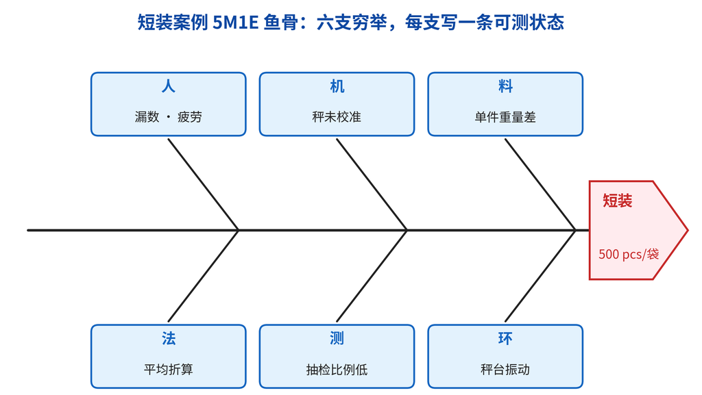

- D4 的任务不是“想出原因”，而是**把假设收敛成一条有证据的因果链**
- 三条路径：鱼骨图发散列全 → 5Why 纵向追问 → FTA 从失效反推必要条件
- 鱼骨图管“不漏”，5Why 管“到底”，FTA 管“逻辑是否成立”
- 顺序：先发散列全，再用数据排除，最后用 5Why 或 FTA 收敛
- 判定：去掉它问题消失、加回它问题重现；两条都做到才算根因
- 反面：把鱼骨图上任意一支当根因，或把“操作不当”当终点

## 5Why 的正确问法：每一问都要有证据

案例（示例数据）：注塑件飞边，不良率 3.2%。

| 层 | 问 | 答 | 证据 |
| --- | --- | --- | --- |
| 1 | 为什么有飞边 | 分型面间隙 0.12 mm，超 0.05 mm 上限 | 塞尺实测 10 点，8 点超差 |
| 2 | 为什么间隙变大 | 分型面磨损，模具已打 38 万模次 | 模具履历卡、磨损痕迹 |
| 3 | 为什么磨损没处理 | 保养按日历 90 天，不按模次 | 保养记录、保养规程 |
| 4 | 为什么按日历 | 规程沿用旧机型经验，未按模次折算 | 规程版本与修订记录 |
| 5 | 为什么没改 | 预防性维护策略未与磨损机理挂钩 | 设备管理制度 |

- 问法三条：问“为什么会这样”而不是“谁干的”；每一答都要落到可查的证据；问到能改的那一层为止
- 错误问法：连问五个“为什么员工不认真”，第五问仍在同一层，等于没问
- 停止标准：再问一次会进入另一条独立因果链，或已追到制度／设计层
- 每条回答都要能被第三方复核：看记录、看实测、看图纸，而不是听讲述

## 鱼骨图 5M1E 在 8D 中的用法

- 鱼骨图（因果图）把结果画在鱼头，把可能原因按 5M1E 分六支挂在鱼骨上
- 5M1E：人、机、料、法、测、环；六支不是平均用力，先用分层数据判断哪一支最可疑

| 支 | 追问 | 本例疑点（短装） |
| --- | --- | --- |
| 人 | 是否按标准作业、是否培训、班次差异 | 计数人员漏数、疲劳 |
| 机 | 参数、保养、精度、工装状态 | 计数秤精度漂移 |
| 料 | 批次差异、来料波动、替代料 | 单件重量差异 |
| 法 | 作业顺序、参数设定、防错是否启用 | 计数方法不统一 |
| 测 | 量具、抽样比例、判定标准 | 称重抽检比例过低 |
| 环 | 温湿度、照明、噪声、场地 | 称重台振动 |

- 在 8D 里它只做一件事：**把假设列全**；它不负责证明，证明要靠数据
- 画法四步：定特性（鱼头写量化缺陷）→ 开六支 → 每支再问两层 → 圈出可验证的疑点；末端要写成“可测量状态”（间隙 0.12 mm），不是“态度不端正”

## 人机料法环查证：把疑点变成数据

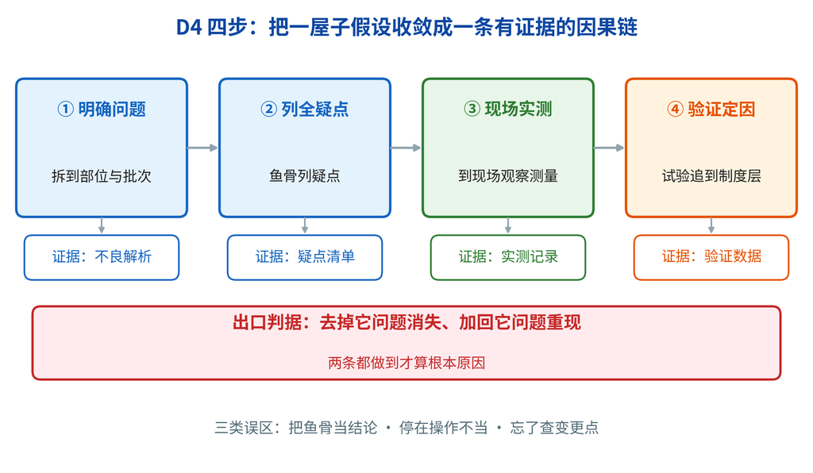

- 查证在现场，不靠回忆：到工位看、按原参数复跑、调当时的记录。
- 六路各有物证：人看排班培训、机看参数日志与校准、料看来料、法看 SOP 与防错、测看量具、环看温湿度与振动。
- 找变更点：4M 与设计变更的日期对齐问题起始日；本例 2 号机保护气 9～11 L/min、减压阀结霜。
- 判据：每个疑点都落到“成立／排除／待查”，并附证据编号。

## 数据验证根因：相关不等于因果

- 分层只能说明“同时出现”，不能说明“谁导致谁”；根因要过三道关
- 第一道 **相关性**：按可疑因子分层，看不良率是否随因子水平跳变
- 本例：保护气低于 12 L/min 组 44/420＝10.48%，不低于 14 L/min 组 14/1,580＝0.89%
- 相对风险 $RR=\dfrac{0.1048}{0.0089}=11.8$，$\chi^2=108.4$（$df=1$，$p<0.001$），关联不是偶然
- 第二道 **时间性**：因子变化要早于不良出现，查参数日志时间戳，不靠回忆
- 第三道 **复现**：把因子调回异常水平看是否重现；10 L/min 焊 20 件，19 件有气孔，15 L/min 焊 20 件，0 件
- 反例：把“夜班不良高”当根因；夜班只是暴露低流量时段的窗口，因子是流量

## 逃逸点分析：为什么没检出

- 8D 实务要回答两个问题：**为什么发生**（occurrence）与**为什么没拦住**（escape）
- 逃逸链三段：过程自检、出厂检验、客户来料检验；任一段失效，缺陷就流到客户
- 本例三段都失效：目视看不到内部气孔；射线只做首件；客户 IQC 每批抽 5 件
- 抽样能力算得清：不良率 2.90%、抽 5 件，检出概率 $1-0.971^{5}=13.7\%$，八成以上漏过
- 逃逸根因四类：检验方法与失效模式不匹配、抽样量不足、判定标准模糊、量具能力不够
- 本例属第一类：内部缺陷只能靠射线或超声，控制计划却把射线限在首件
- 判据：每段回答“当时靠什么拦、为何没拦住”，并给出改进后的拦截方式

## D4 的输出：根因与逃逸根因双重确认

- D4 的交付物不是一段解释，而是**两条经验证的因果链＋一份证据清单**
- 发生根因：为什么会产生缺陷——本例是减压阀结霜使保护气流量低于 12 L/min
- 逃逸根因：为什么没检出——本例是控制计划只规定目视与首件射线，过程参数无监控
- 五条验收判据：能复现、能去除、能加回、有证据编号、指向可改的层级
- 只写“操作不当”“员工疏忽”的一律退回：既不可改，也不可验证
- 输出三件套：一句根因陈述、一张证据表、一条 5Why 链，齐了才算关闭 D4
- 判据之外还有一条：根因要能解释 D2 里全部的“是”与“不是”，解释不了就还没到底

## NTF 不再现：查不出的 8D 怎么做

> 上一页要求根因“能复现”，可工程里最常见的结局，恰恰是客户有、我们重现不了。
- **NTF**（No Trouble Found，不再现）：客户侧失效、返厂后在规定条件下复现不出；不是“没问题”，是“条件没找对”
- 五步流程：确认生产日期 → 拍照留证 → 按正常流程复跑记录 → 查当时 FTT 与同批不良史 → 对齐人机料法环变化点
- FTT 算例（示例数据）：异常批 $8{,}200/10{,}000=82.0\%$，正常批 $9{,}500/10{,}000=95.0\%$，差 13 个百分点
- 扩条件不现时：温度、批次、装夹、通电时长逐项加严，把“试过哪些条件”写成矩阵；再取客户使用条件与在役跟踪
- 判定：能复现就回 D4；不能复现也要给边界条件清单与监控方案（如 500 台跟踪 3 个月），不能以“经查无问题”关闭
- 反例：“经查无问题，属客户误判”最容易被客户退回——客户要的是证据，不是免责
- 判据：复现矩阵有样本数、有判定、有结论；监控有计划、有责任人、有观察窗

**结论：NTF 不是证据不足的借口，而是 8D 里需要另一套证据的分支。**

## 问题描述案例：焊缝气孔投诉

教学案例（示例数据）：钢制电池托架，MIG 焊，焊缝总长 180 mm，图纸要求 100 mm 内气孔不超过 2 个。

| 要素 | 本例写法 | 数据来源 |
| --- | --- | --- |
| What | 焊缝内部气孔，单件最多 6 个，超图纸上限 2 个 | 客户退回样件、射线底片 |
| Where | 2 号焊机夜班工位 W-07；白班 1 号机正常 | 报工记录、设备编号 |
| When | 2024-09-08 夜班 22:00 后开始，09-13 客户装配线发现 | 首件记录、客户邮件 |
| How many | 装配线已用 2,000 件中 58 件，2.90%；夜班 46/800＝5.75%，白班 12/1,200＝1.00% | 客户退货清单 |
| Impact | 客户停线 2 h，按 60 台/h 计 120 台；同批 8,000 件需逐段排查 | 停线通知、排查记录 |

- 一句话陈述：某托架 2 号焊机夜班焊缝内部气孔，装配线已用 2,000 件中 58 件（2.90%）不合格，客户停线 2 h
- 夜班 5.75% 是白班 1.00% 的 5.75 倍，问题与班次、设备强相关，这就是 D4 的入口
- 范围已界定：1 个客户、1 条线、2 个班次、1 台设备；范围外的先不查
- 5W2H 不必七问都写进正文，但七个问题都要能当场答出来

## 案例：焊接气孔的 D1 到 D4

- D1：质量经理任组长，成员含焊接工艺、设备、检验、采购与客户接口人，共 6 人
- D2：出货 3,200 件，装配线已用 2,000 件中 58 件气孔（2.90%），夜班 5.75%、白班 1.00%，集中在 2 号焊机
- D3：全批 8,000 件逐段排查，累计确认 237 件（2.96%）；客户处补货 1 批，在途 800 件改道返厂
- D4 查证：2 号机保护气实测 9～11 L/min（标准 15±2），减压阀结霜，气瓶间相对湿度 85%
- 5Why：气孔→保护不足→流量低→阀结霜→气瓶间无除湿→气路设计规范缺湿度与流量下限要求
- 逃逸：控制计划只做目视与首件射线，过程参数无监控、无报警
- 结论：发生根因是气路设计规范缺失加减压阀结霜；逃逸根因是检验方法与失效模式不匹配

## 8D 与 FMEA、控制计划的关系

- 三者是同一条信息链：FMEA 预判失效、控制计划规定怎么防、8D 处理漏网的失效
- 8D 的输入来自这两份文件：查当时识别的失效模式、频度与探测度是否被低估

| 文件 | 8D 从中取什么 | 8D 回写什么 |
| --- | --- | --- |
| PFMEA | 当时的失效模式、S／O／D、预防与探测措施 | 补新失效模式、修正 O／D、加预防措施 |
| 控制计划 | 检什么、怎么检、抽多少、谁判 | 加流量下限与报警、改抽样量 |
| 作业指导书 | 参数设定与操作步骤 | 改参数范围、加开机点检项 |

- 回写要具体到行：本例把“保护气流量低”补进 PFMEA，控制计划加流量下限报警
- 不回写的 8D 等于没做 D7，同类问题明年会以另一个批次号再来
- 判据：关闭时能拿出三份文件的修订记录，且修订日期早于关闭日期

## 8D 与 DMAIC：同构、不同用途

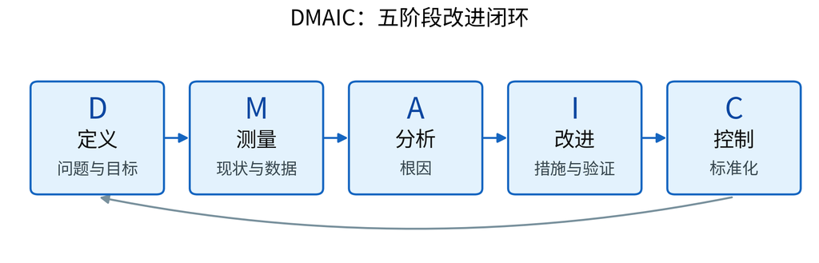

- 同构：都是“定义问题—找真因—改—固化”的闭环，都能映射 PDCA。
- 差别在入口与周期：8D 客户投诉触发、以周计；DMAIC 项目立项触发、以月计。
- 8D 多止血（D0／D3），DMAIC 多测量深度（MSA、过程能力、假设检验）。
- 选用：客户答复走 8D，内部降本走 DMAIC；D4 可直接借用 DMAIC 的分析工具。

## 8D 报告格式与写作要点

- 报告是一张可核查的表，不是一篇作文：表头加 D0～D8 逐栏，栏栏有数据
- 写作五条：用数据不用形容词、写证据编号、区分“已做”与“未做”、时间写承诺与实际两列、附件单独编号

| 区块 | 写什么 | 附件证据 |
| --- | --- | --- |
| 表头 | 产品、批次、客户、数量、日期、组长 | 发货单、追溯码 |
| D0～D3 | 响应、团队、问题陈述、围堵与验证 | 照片、全检记录 |
| D4 | 发生根因、逃逸根因、证据链 | 分层数据、复现试验 |
| D5～D8 | 措施、实施、文件修订、关闭 | 修订页、客户确认 |

- 一页纸原则：客户管理层只看第一页，第一页要能说清问题、根因、措施、效果
- 附件清单：不良照片、分层数据、5Why 链、试验记录、文件修订页、客户确认
- 反例：整页“加强管理、提高意识”，没有一个数字与日期

## 常见错误：五类最容易被退回的写法

- 五类错误同源：把现象当原因、把措施当原因、缺**证据编号**。

| 写法 | 问题 | 后果 | 改法 |
| --- | --- | --- | --- |
| 原因写“操作不当” | 不可改、不可验证 | 同类问题复发 | 追到制度或设计层 |
| 围堵只做厂内 | 在途与客户仍流出 | 二次投诉 | 六处全覆盖并验证 |
| 根因只有推理 | 无复现、无数据 | 措施无效 | 补复现试验 |
| 措施写进原因栏 | 原因与措施不分 | D5 无的放矢 | 分两栏写、逐条对应 |
| 永久措施只写培训 | 无控制手段 | 三个月后复原 | 改控制计划与防错 |

- 改法：每条结论追问三句——数据在哪、谁验的、能否重现；答不上就退回。
- 课堂用法：拿一份真实 8D 按表逐行打勾，缺一项即判退回。

## 防错设计：换型防错、定置管理、称重分包

> 上一页说“永久措施只写培训”会被退回，这一页给可替代的具体手段——让错误根本做不出来。
- 三招：**换型防错**（不该出现的料、标签、程序撤离或封盖，按点检表逐项签名）、**定置管理**（一萝卜一个坑）、**校验防错**（扫码、计数、称重三选一）
- 定置管理落到摆放：待加工在左、已加工在右，不合格品与调试件专区标识，严禁混放
- “加强”要量化：原来 10 个检 1 个，加强到 5 个检 1 个；培训也要写方法、考核与上岗初期互检
- 称重判据：小包装总重的标准差要小于单件重量的 1/6，称重才可能分辨出少一件
- 算例（接短装案例 8 袋数据）：$\sigma=2.921$ g，单件 $m=6.4672$ g，$m/6=1.078$ g，$\sigma>m/6$，称重计数不可靠
- 分包反推：若 $\sigma$ 与 $\sqrt{n}$ 同阶，$n_{\max}=500\times(1.078/2.921)^2\approx68$ 件；取 50 件/小包，$\sigma'=2.921\times\sqrt{50/500}\approx0.924$ g $<1.078$ g
- 案例里的 3,233 g 是保守下限（低了补 1 件），不能当计数依据；要让称重可判，先分包
- 判据：每条对策都要回答“改了什么装置或文件、怎么验证、复发怎么发现”，答不上就是空话

**结论：防错不是更努力地检，而是让错误根本做不出来。**

## D0～D4 的完成标准：五道门禁

- 门禁的作用：每一步有明确的“可进入下一步”判据，避免带着漏洞往前跑

| 步骤 | 交付物 | 放行判据 |
| --- | --- | --- |
| D0 | 启动决定、客户沟通记录 | 客户已保护、信息齐全、时限已承诺 |
| D1 | 团队名单、分工表、会议计划 | 角色与授权明确、五阶段有人负责 |
| D2 | 量化问题陈述、是／不是表 | 可量化、可追溯、范围清晰 |
| D3 | 围堵方案、全检记录、验证数据 | 六处覆盖、筛出率一致、零新增 |
| D4 | 根因陈述、证据表、5Why 链 | 双重确认、五条判据全过 |

- 判据一律可核查：有交付物、有数据、有签字，不认“基本完成”
- 带着 D2 的模糊范围进 D4，后面所有数据都不可比
- 用法：贴进报告首页逐格打勾并签字，客户审阅时一眼看出卡在哪；签字人对“能否放行”负责
- 缺哪一道就在哪一道返工，不要用后面的步骤弥补前面的漏洞

## 8D 团队会议怎么开

- 会议唯一的产出是**决策与待办**，不是“大家讨论一下”
- 固定议程（60 分钟）：数据回顾 10 → 根因讨论 20 → 措施与责任人 15 → 风险与升级 10 → 记录确认 5
- 三条规矩：带数据来、只讨论本步、每条待办有名字和日期
- 主持人控场：跑题记到“停车场”会后处理；争议用数据裁决，不用职位
- 记录模板：日期、出席、数据结论、决策、待办（谁／何时／交付物）
- 升级机制：两次会议无进展，升级到发起人或客户接口人
- 判据：会后 24 小时内发出纪要，待办排在下次会议第一项

## 案例讨论：根因到底在哪一层

- 讨论题：某螺栓装配线扭矩衰减投诉，直接原因、流出原因、系统原因各在哪一层
- 现象：3 批共 1,500 台，12 台扭矩低于下限；客户停线 4 h，全部返修
- 直接原因：拧紧枪套筒磨损，扭矩输出偏低 8%
- 流出原因：终检每批只测 3 台，且用同一把枪复测，缺陷被同一偏差掩盖
- 系统原因：套筒更换按日历不按拧紧次数；终检未规定用独立量具复测
- 讨论：哪一层今天能改、哪一层要改制度、哪一层要改设计
- 结论：三层都写进 D4，D5 的措施分层落地，不能只改最上面一层

## 推导留给 AI：8D（一）（汇总）

- 把 D0～D8 映射到 PDCA 四个阶段，说明每一步的“证据”是什么
- 为 D3 的六个隔离位置各设计一个“可疑品数量”的确认方法
- 5Why 何时停止？给出三条可判定的停止标准
- 如果 D4 的根因无法复现（NFF），D5～D7 应该怎样调整？

## 本部分小结：D0 到 D4 的一条证据链

- D0 判要不要做、先保护顾客；D1 定谁来做；D2 把问题说成数字
- D3 先止血并验证止血有效；D4 找发生根因，也找逃逸根因
- 一条主线：**症状 → 问题 → 范围 → 围堵 → 根因**，每一步都在缩小不确定性
- 三件工具各司其职：鱼骨图列假设、5Why 追到底、分层与复现做验证
- 三个数要记住：2.90%（批次不良率）、2.96%（围堵筛出率）、13.7%（抽 5 件的检出概率）
- 一条纪律：没有证据编号的结论，不进报告
- 下一部分：D5～D8 与软件开发流程，看措施怎样落地、文件怎样改

# 第四部分 · 第 4 内容块：8D 报告（二）与软件开发流程

- 一个完整案例：显示屏模组“短装”投诉走通 8D
- 每一步给出数据、判定与财务节余核算
- 软件开发五阶段（调研→蓝图→实施→上线优化→持续改进）
- 8D 与软件开发流程的对应；伦理落点：预防再发即责任闭环

## D5 制定永久纠正措施（选择／验证）

- 目标：消除 D4 验证过的根因，不是压住症状
- 输入：根因证据、临时措施、风险约束、客户要求
- 候选：头脑风暴＋FMEA／因果图，至少两套方案
- 筛选：针对根因、现场可执行、可测量、无新增风险
- 验证：小批试产／模拟／DOE，设对照与判定阈值
- 记录：验证条件、样本、数据、结论、残余风险
- 输出：推荐方案与验证报告，交 D6 全面实施
- 纪律：培训、加严检验通常只能作配套，不能单独当永久措施

> 没有验证数据的措施，只是另一个假设。

## 措施选择矩阵（效果／成本／风险）

以短装案例的三套候选措施为例，评分为教学设定。

| 方案 | 效果／成本／风险 | 结论 |
| --- | --- | --- |
| A（4.3） | 5／4／3 | 计数＋称重复核，推荐 |
| B（3.4） | 4／2／4 | 自动计数机，投入高 |
| C（3.4） | 3／5／2 | 只加严抽检，不治根 |

- 评分 1～5 分；效果越高越好，成本与风险越低越好
- 示例权重 $w=(0.5,0.3,0.2)$，得分 $S=0.5E+0.3C+0.2R$
- A 胜出的关键：效果满分，成本与风险可接受
- 矩阵只排序；A 仍须小批验证后才能进 D6

## D6 实施与验证（小批／试产／数据对比）

- 计划：任务、责任人、日期、资源、验收标准
- 小批：先一条线／一个班次／一个客户，设停线条件
- 试产：连续多批，覆盖不同班次、物料、设备
- 对比：同口径的前后数据（PPM、投诉起数、返工工时）
- 固化：作业指导书、控制计划、检验规范同步生效
- 退出：补发、全检、加严检验按计划废除
- 判定：效果达标＋无新增风险＋文件已生效
- 若未达标：回到 D4，不调低标准凑结论

## D7 防止再发生（标准化／FMEA 更新／CP 更新）

- 制度层：变更管理、供应商管理、考核规则
- 方法层：作业方法、参数设置、防错方式
- 程序层：作业指导书、检验规范、异常处置流程
- 设计层：设计规范、材料规格、公差与安全裕量
- FMEA：补上新失效模式，重评 $S$、$O$、$D$
- CP：把新控制方法写进控制计划，明确频次与反应计划
- 横展：同系列产品、同类产线、同类供应商
- 判定：文件已发布＋培训有记录＋现场可核对

## D8 团队表彰与关闭（知识沉淀）

| 关闭检查 | 要回答的问题 | 证据 |
| --- | --- | --- |
| 根因 | 是否已验证并复现？ | D4 记录 |
| 措施 | 是否有效且无新风险？ | D6 对比 |
| 固化 | 文件与培训是否到位？ | D7 清单 |
| 客户 | 客户是否认可？ | 签署或邮件 |

- 表彰要具体：点名团队与个人，说明贡献，不只发通知
- 复盘要留痕：8D 报告、教训卡、横展清单进知识库
- 财务节余由财务确认，扣掉投入后再公布
- 关闭签字即承诺“不再发生”，不是流程终点

## 8D 有效性评估（复发率／周期）

| 指标 | 定义 | 判读 |
| --- | --- | --- |
| 复发率 | 观察窗内同根因再发数／已关闭数 | 越低越好 |
| 平均关闭周期 | 关闭日期减启动日期，取平均 | 越短越好 |
| 一次通过率 | 首次评审通过数／提交数 | 越高越好 |
| 措施落实率 | 到期已完成措施／到期措施 | 接近 100% |

- 复发率公式：$R_{\mathrm{re}}=N_{\mathrm{re}}/N_{\mathrm{cl}}\times100\%$
- 周期公式：$\bar{T}=\frac{1}{N}\sum_{i=1}^{N}(t_i-t_{0,i})$
- 目标值由企业历史基线设定，不拍脑袋
- 评估看趋势与分层（客户／产品／根因）
- 周期不能靠压缩 D4／D6 换取，否则是假关闭

## 8D 与其他质量工具的关系

- 8D 是骨架，FMEA、SPC、5Why、DOE 是节点工具。

| 步骤 | 使用工具 | 产出证据 |
| --- | --- | --- |
| D4 找因 | 5Why、鱼骨图、SPC | 分层数据、复现试验 |
| D5 选措施 | FMEA、DOE | 措施验证数据 |
| D6 验证 | SPC 控制图 | 前后对比、Cpk |
| D7 固化 | FMEA、控制计划 | 三份文件修订页 |

[figure not shown]

- 上游输出是下游输入；工具产出证据，不能倒过来。

## 案例开场：短装不是坏了，是数量对不上

**D0 征兆紧急反应**

- 客户投诉：某型号显示屏模组**短装**——标称 500 pcs/袋，客户产线发现数量不足，导致缺货停线
- 立即动作：先补发保产线，同时成立 8D 小组、冻结同批次库存
- 判据：顾客已保护、批次与流向清楚、缺陷可量化到“袋／件”，三条齐了才进 D1

**D1 核心团队（5 人）**

| 成员 | 职能 | 成员 | 职能 |
| --- | --- | --- | --- |
| 张** | 生产 | 王** | 采购 |
| 王** | 品质 | 张** | 跟单 |
| 徐** | 包装 | — | — |

- **D2 已到位**：标称 500 pcs/袋，短装已量化到袋数、锁定批次与客户——这问题必须查计数与称重，而不是查产品本身

## D3 对策：先补货止血，再全检控范围

| 序号 | 临时对策 | 责任担当 | 导入日期 |
| --- | --- | --- | --- |
| 1 | 统计客户处缺少的具体数量，并向客户补充提供 | 徐** | 2024-05-18 |
| 2 | 已确认库存中打包完成的产品（全检称重） | 张** | 2024-05-25 |

- 覆盖：顾客端（补发）＋成品仓（全检）＋在制与在途（拦截）＋供应商端（已评估，未发现来料问题）
- **为什么**：D3 的关键不是“补发”，而是在根因未明前阻止问题继续流出
- 判据：顾客已隔离（补发到位）、可疑品范围明确（成品仓全检）、措施有效（客户停线解除）

## 排除法：五个分支，逐个给证据

| 分支 | 证据 | 判定 |
| --- | --- | --- |
| 人员 | 抽查多时段监控与日常观察：包装员工作认真、无漏取与舞弊 | 排除 |
| 机器 | 电子秤送第三方机构校准，误差在可接受范围 | 排除（非主因） |
| 物料 | 裁线长度与焊锡量差异，导致同数量产品总重不同 | **主要原因** |
| 方法 | 取样 20 pcs 算平均单重再称总重，无法保证精确 500 pcs | 次要原因 |
| 环境 | 天气炎热，风扇直吹电子秤与包装员，影响称重精度 | 次要原因 |

- 排除的写法：不是“应该没问题”，而是“**抽查了什么、结果如何**”
- 主因定 D5 的方向，次因定配套措施——三者都要覆盖
- 判据：每个分支都有“成立／排除／待查”的结论，并附证据编号

## 8 袋重量：两个边界证明称重法失效

客户处退回与库存抽样的 8 袋（每袋 500 pcs）实测重量：

| 编号 | 1# | 2# | 3# | 4# | 5# | 6# | 7# | 8# |
| --- | --- | --- | --- | --- | --- | --- | --- | --- |
| 重量 | 3,234.8 g | 3,233.3 g | 3,231.9 g | 3,233.1 g | 3,233.8 g | 3,228.4 g | 3,238.7 g | 3,235.0 g |

- 统计：均值 **3,233.6 g**，极差 **10.3 g**；折算单件 6.4672 g，单件范围 6.4568～6.4774 g
- 判据一：少 1 pcs 的最重可能 $499\times6.4774=3{,}232.2$ g，**＜ 3,233 g**
- 判据二：满 500 pcs 的最轻可能 $500\times6.4568=3{,}228.4$ g，**＜ 3,233 g**
- 结论：两个区间**重叠**，单靠总重无法区分 499 与 500——这就是称重计数法失效的定量证据

## 根因：标准里缺一条下限规则

1. 为什么短装？→ 按总重折算件数，重量偏低时被判为不足
2. 为什么重量偏低？→ 单件重量波动（裁线长度、焊锡量差异）
3. 为什么波动未被发现？→ 只按平均单重折算，未做件数复核
4. 为什么只靠称重？→ 作业指导书只规定称重法，没有重量下限规则
5. 为什么没有下限规则？→ 包装作业标准未定义“重量—数量”双重校验
- **根因**：包装作业标准缺少双重校验规则（标准层）；直接诱因是物料单重波动
- 判定（可核查）：加上 3,233 g 下限与复核规则后投诉归零；换回旧标准问题重现
- 结论：根因不是“包装员不认真”，而是**标准本身不能保证 500 pcs**

## D5 措施：3,233 g 这条阈值怎么反推

| 针对 | 改善前 | 改善后 | 责任 | 完成 |
| --- | --- | --- | --- | --- |
| 物料重量差异 | 计数包装：取样算平均单重，再看总重 | 计数＋计量：增加确认总重；500 pcs 总重低于 3,233 g 时再放入 1 pcs；每批加 0.1% 备品 | 张**、徐** | 即日起 |
| 测量环境 | 未规定电子秤状态 | 称重前确认电子秤水平、四脚无悬空 | 徐** | 即日起 |

- 阈值来历：由 D4 判据反推——**大于 499 pcs 的最大可能重量 3,232.2 g**，低于阈值必补 1 pcs
- 代价：可能出 501 pcs（偏多），用 0.1% 备品与客户协议吸收；**宁可多 1 件，不可少 1 件**
- 判据：覆盖主因（物料）与次因（方法、环境）、可执行、可验证、不引入新风险

## D6 验证：控制图加投诉数，缺一不可

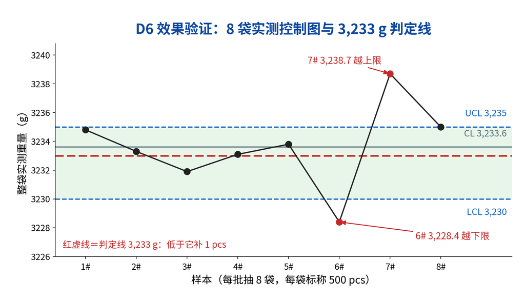

- 控制限由 8 袋实测值建立：UCL 约 3,235 g、LCL 约 3,230 g，逐批描点监控
- 前后对比：改善前 3 个月客户短装投诉 **8 起**；改善后 6 个月 **0 起**（情景数据）
- 读图：6#、7# 越界是建立判定线用的**原始数据**；改善后按同一规则监控，未再出现 <3,233 g 批次
- 判据：有实施证据（作业指导书、称重记录）＋控制计划已更新＋数据可追溯，三条齐才算 D6 关闭

## D7／D8：固化进指导书，算清 49.4 万元

**D7 预防再发生**

- 作业方法固化为**作业指导书**，悬挂作业台；责任赵**，2024-05-30 完成
- 举一反三：同系列型号与另一条包装线同步修订，纳入新员工培训与考核
- 判定：文件已发布、培训有记录、现场可核对

**D8 关闭与财务节余（情景估算，参数按企业实际替换）**

| 项目 | 计算 | 结果 |
| --- | --- | --- |
| 单起质量成本 | 补发 1,000 pcs×8 元＋客户停线 2 h×5,000 元/h＋运费 1,200 元 | 19,200 元/起 |
| 年化损失 | 32 起/年×19,200 元 | 61.4 万元/年 |
| 备品投入 | 3 万袋×500 pcs×0.1%×8 元 | 12.0 万元/年 |
| 净节余 | 61.4－12.0 | 49.4 万元/年 |

- 关闭条件：缺陷率稳定下降＋质量部复核＋客户确认＋关闭日期，四项齐全

## 外观、标签、短装、漏加工、错料：五类缺陷的改法

> 案例里的短装只是五类常见缺陷之一；客户最反感的，是把五类都写成“操作失误、加强培训”。

| 缺陷类型 | 常被退回的写法 | 系统改法 | 可查证据 |
| --- | --- | --- | --- |
| 外观缺陷 | 加强目视、处罚当事人 | 标准图文并茂＋限度样件；光照与观察路径固化；源头防磕碰 | 限度样件、光照记录 |
| 标签贴错 | 培训操作工、加强复核 | 现场打印随用随打；换型时旧标签撤离或封盖 | 打印记录、换型点检表 |
| 数量短缺 | 增加互检、加强点数 | 整齐排列；吸塑盒一位一件；称重分包 | 排列规范、分包 $\sigma$ |
| 漏加工 | 加强自检、处罚 | 自检互检制度化；定置管理；料架挂随行卡 | 随行卡、定置照片 |
| 发错料 | 操作失误、责任心 | 换型防错、5S；调试件与不合格品专区；首件确认 | 换型点检、首件记录 |

- 共同点：不缺态度，缺装置、布局与标准；把责任推给操作工，问题照样复发
- 课件原话：责任推给操作工，要么是应付，要么是不懂质量管理
- 判据：措施要指向可改的对象（标准、工装、布局、程序），并横展到同类工位
- 与 D5 对接：每套改法都要有前后数据——漏检率、错料起数、$\sigma$ 变化
- 课堂用法：拿一份被退回的 8D，按五类归档，再逐条改写

**结论：五类缺陷的根子都在系统，改法也都在系统；写“加强”不如改一条标准。**

## 质量问题处理流程与 8D 嵌入

| 环节 | 动作 | 输出 |
| --- | --- | --- |
| 入口 | 投诉、巡检、审核、售后 | 问题单 |
| 分级 | 安全、批量、重复、客户要求 | 是否启动 8D |
| 快速处置 | 不启动 8D 时用快速反应／5Why | 处置记录 |
| 8D | D0～D8，对接纠正措施与变更 | 8D 报告 |
| 关闭 | 效果复核、知识入库、横展 | 关闭批准 |

- 分级不是降级：涉及安全与批量必须升级
- 8D 不是唯一通道，但重复问题应走 8D
- 关闭后把措施写回 FMEA、控制计划与培训教材

## 软件开发流程总览

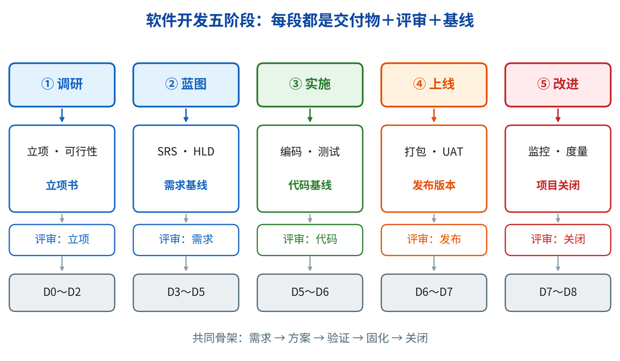

- 主线：启动→计划→需求→设计→编码→测试→发布→验收→关闭。
- 两条链：SRS→HLD→LLD；UT→IT→ST→UAT。
- 测试与设计同步：STP 对 SRS、ITP 对 HLD、UTP 对 LLD。
- 每阶段三件套：文档、评审、基线；阶段门过基线才放行。
- 配置库贯穿需求、设计、代码与基线；需求稳定用瀑布，多变用迭代。

## 软件项目组：十类角色与阶段输入输出

> 上一页给出流程骨架，这一页回答每一步“谁做、拿什么做、交出什么”。

| 阶段 | 主责角色 | 输入 | 关键输出 |
| --- | --- | --- | --- |
| 立项 | SE、TM、资料 | SOW／AR | 评审记录、估计表、技术解决方案建议书 |
| 计划 | SE、TM、CMO | SOW／AR、设计规格 | PPL、QAP、TSP、CMP、RMP 及评审记录 |
| 需求 | SE、SWE、TM | SOW／AR、设计规格 | SRS、STP、重估计表 |
| 设计 | SE、SWE、TM | SRS、PPL | HLD／ITP／ITC、LLD／UTP／UTC |
| 编码测试 | SE、SWE、TE | PPL、LLD、用例 | 代码、走读记录、测试脚本与报告 |
| 收尾 | SE、TM、QA | PPL、验收标准 | UAT 记录、项目经验总结 |

- 角色分三组：管理（PM、SEPG）、工程（SE、SWE、TE、TM）、保障（QA／QAM、CMO、MC、资料人员）
- 计划与设计同步：STP 对 SRS、ITP 对 HLD、UTP 对 LLD；计划不跟着设计走，测试就永远迟到
- 收尾两件事：UAT 四步（验收准备、初步验收、最终验收、报告总结）＋项目关闭的经验总结
- 日常动作：周报、Timesheet、周例会、培训、配合 QA 审计、向 SEPG 提改进建议
- 判据：任取一个交付物，都能说出谁写、谁审、谁批准、存在哪个配置库里

**结论：流程不是步骤清单，是“角色—输入—输出”的责任矩阵。**

## 软件交付物与配置管理：谁管基线

> 角色定了，接着问：每一步交出的文档叫什么、由谁收进基线。
- 交付物两族：**产品文档**（SRS、HLD、LLD、测试计划与用例、VDD）与**管理文档**（PPL、QAP、CMP、RMP、TSP、WBS、PTF、TimeSheet、MTS）
- 测试文档成对：STP／STC、ITP／ITC、UTP／UTC——有测试计划就要有用例
- 配置管理三件事：建配置库、划基线、做配置审计；配置状态报告定期发布
- 三条基线：需求（SRS 通过评审）、设计（HLD、LLD 入库）、产品（发布版与 VDD 对应）
- 变更纪律：进基线后的变更走申请、影响分析、评审、重基线四步，不能口头改
- 度量文档 TimeSheet 与 MTS 提供工作量与缺陷数据，是估计表更新的依据；缩略语先背八个：SOW、AR、PPL、SRS、HLD、LLD、STP、VDD
- 判据：任取一个需求变更，能追到受影响的设计、代码、用例与测试记录

**结论：文档不是形式，是让“谁改了什么”可追溯的账本。**

## 需求分析（用户故事／需求规格）

| 载体 | 回答的问题 | 典型内容 |
| --- | --- | --- |
| 用户故事 | 谁、要什么、为什么 | 角色／目标／价值 |
| 验收条件 | 怎样算做完 | Given／When／Then |
| SRS | 系统必须满足什么 | 功能、性能、接口、约束 |
| RTM | 需求是否被实现与验证 | 需求↔︎设计↔︎代码↔︎用例 |

- 用户故事写给业务听，SRS 写给开发和测试看
- 好需求可验证：有输入、输出、阈值与异常
- 需求基线后变更要走申请、影响分析与评审
- 追溯矩阵是防止“漏做”和“镀金”的账本

## 概要设计与详细设计

| 维度 | 概要设计（HLD） | 详细设计（LLD） |
| --- | --- | --- |
| 关注 | 系统怎么分块 | 每块怎么实现 |
| 内容 | 架构、模块、接口、数据模型 | 类／函数、算法、表结构 |
| 约束 | 性能、安全、部署 | 异常、日志、边界条件 |
| 验证 | 集成测试计划 | 单元测试计划 |

- 设计原则：高内聚、低耦合、接口先行、信息隐藏
- HLD 评审通过才进 LLD；LLD 评审通过才编码
- 设计文档要能回答“变更会影响谁”
- 基线：HLD／ITP、LLD／UTP 分别入库

## 编码与代码规范

- 规范：命名、格式、注释、异常、日志、安全
- 一条规则只做一件事；函数短、参数少、副作用清楚
- 提交前：本地测试通过、静态检查无阻断、代码走读
- 评审看五件事：正确、可读、可测、安全、可维护
- 禁止：魔法数、复制粘贴、吞异常、硬编码密钥
- 代码基线：每次合并可构建、可测试、可回退
- 技术债登记：先记录、再排期，不假装不存在
- 代码规范不是审美，是降低协作成本

## 测试（单元／集成／系统／验收）

| 层级 | 对象 | 主要方法 | 通过标准 |
| --- | --- | --- | --- |
| 单元测试 | 函数或类 | 白盒、边界、异常 | 覆盖率与关键断言 |
| 集成测试 | 模块与接口 | 接口、契约、数据流 | 接口一致、无阻塞 |
| 系统测试 | 完整系统 | 场景、性能、安全 | 满足 SRS |
| 验收测试 | 用户业务 | UAT、试用、回归 | 用户签字 |

- V 模型：UT 对 LLD、IT 对 HLD、ST 对 SRS、UAT 对用户需求
- 测试用例要能失败；只写“正常路径”不算测试
- 缺陷发现越晚，修复成本越高；能左移就左移
- 回归测试保证“改一个、不坏一片”

## 版本管理与持续集成

- 版本：语义化版本，主版本、次版本、修订号
- 分支：主干可用；功能分支短命；发布分支只修缺陷
- 基线：需求、设计、代码、构建产物一一对应
- CI：提交→构建→静态检查→单元测试→制品
- 纪律：小步提交、主干常绿、失败即停
- 制品：可重复构建，版本号不可变
- 环境：开发／测试／预发／生产隔离
- 发布标签：每次发布可定位到代码与制品

## 发布与部署（灰度／回滚）

- 发布前：go／no-go 评审，确认测试、变更、回滚
- 部署：先预发，再小流量，再扩大，最后全量
- 灰度：按用户／租户／产线分批，观察错误率与时延
- 特性开关：代码先上，功能后开，按需关闭
- 回滚：保留上一版制品；数据库变更要可逆或兼容
- 触发：错误率、时延、业务指标异常即回退
- 记录：发布时间、版本、变更单、回滚点

## 运维与缺陷管理

- 监控四件套：指标、日志、链路、告警
- 事件分级：P1 中断／P2 严重降级／P3 一般／P4 咨询
- 缺陷生命周期：新建→确认→分配→修复→验证→关闭
- 缺陷单必须写：版本、环境、复现步骤、影响范围
- 重复缺陷要并单；复发缺陷要回到根因
- 复盘只看系统，不找人背锅；行动项要有责任人与日期
- 知识库：把典型故障写成可执行的排查手册

## 敏捷开发与 Scrum（迭代／看板）

| 要素 | Scrum | 看板 |
| --- | --- | --- |
| 节奏 | 固定长度迭代 | 连续流动 |
| 计划 | 产品待办→迭代待办 | 按容量拉取 |
| 角色 | 产品负责人、Scrum Master、团队 | 团队自组织 |
| 度量 | 增量与回顾 | 周期时间、在制品 |

- Scrum 四会：计划、每日站会、评审、回顾
- 迭代长度 1～4 周，迭代内原则上冻结需求
- 看板用 WIP 上限暴露瓶颈，不是画块板就叫看板
- 敏捷不是不要文档，而是文档够用、可验证

## DevOps 与 CI／CD

- DevOps＝文化＋自动化＋度量＋共享，不是工具堆
- CI：每次提交自动构建与测试，尽早发现集成问题
- CD：持续交付“随时可发”；持续部署“自动到生产”
- 流水线：代码→构建→测试→安全扫描→制品→部署
- 基础设施即代码：环境可复制、可审计、可回滚
- 可观测性：上线后能看见错误、时延与业务指标
- DevSecOps：安全门禁左移到需求与代码阶段

## 软件质量与可靠性（缺陷密度／MTBF）

| 指标 | 公式 | 说明 |
| --- | --- | --- |
| 缺陷密度 | $D=N_d/K$ | 每千行代码缺陷数 |
| MTBF | $\mathrm{MTBF}=T/N_f$ | 平均无故障时间 |
| 可用度 | $A=\mathrm{MTBF}/(\mathrm{MTBF}+\mathrm{MTTR})$ | 稳态可用比例 |

- 算例：20 KLOC 发现 12 个缺陷，$D=0.6$ 个/KLOC
- 算例：累计运行 10000 h、故障 5 次，MTBF 为 2000 h
- 若 MTTR 为 4 h，可用度为 99.80%
- 指标要同口径比较；缺陷密度低不等于质量好

## 制造业软件与 MES／ERP 开发的特点

- 两套语言：ERP 讲计划与财务，MES 讲工单与现场
- 实时性：MES 要秒级响应，停机就是产量损失
- 集成：PLC、SCADA、条码、AGV、称重设备
- 数据：主数据、批次、序列号、工艺参数、审计追踪
- 现场：断网可降级、操作防错、界面适合手套操作
- 变更：生产不能停，升级要灰度、可回滚
- 合规：电子记录、权限分离、变更留痕

## 8D 与软件工程：同构的五个关口

| 关口 | 8D | 软件 | 共同判据 |
| --- | --- | --- | --- |
| 看清问题 | D2 量化 | 需求与验收条件 | 可验证 |
| 控制影响 | D3 遏制 | 热修复或开关 | 先止血 |
| 找根因 | D4 验证 | 缺陷定位 | 可复现 |
| 验证措施 | D5／D6 | 修复与回归 | 前后对比 |
| 固化关闭 | D7／D8 | 基线加复盘 | 不再发生 |

- 同构的是“证据链”，不是表格形式
- 差异：8D 被动响应，软件可主动设计质量
- 会用 8D 的思维看缺陷，代码评审会更有针对性

## 案例：质量管理系统模块的开发

| 阶段 | 交付物 | 验收要点 |
| --- | --- | --- |
| 需求 | 用户故事、SRS、RTM | 三类角色可核验 |
| 设计 | HLD／LLD、数据模型 | 工单到 8D 可追溯 |
| 开发 | 代码、单元测试、CI 流水线 | 规则可配置、审计留痕 |
| 测试 | UT／IT／ST／UAT | 历史缺陷回放 |
| 发布 | 灰度、回滚方案 | 试点线通过再全厂 |

- 教学案例：某汽车零部件企业的质量模块
- 角色：质检员、质量工程师、质量主管
- 场景：来料检验、过程巡检、不合格品、8D 归档
- 难点：ERP／MES 主数据对齐，权限与审计
- 验收：8D 单可追到批次，措施可追到文件

## 伦理（一）：预防再发即责任闭环

- 8D 的 D7 决定这次改进是“闭环”还是“表演”：
  - **闭环**：改制度、改程序、改设计规范，问题不再发生 → 责任尽到
  - **表演**：只写“加强培训、提高意识、处理责任人” → 问题必然复发
- 责任主体是明确的：**8D 负责人、批准人、客户 8D 负责人**在报告上签字，签字即对“不再发生”负责
- 三个可核查的判据：
  - 措施是否针对 D4 验证过的根因（不是“万能培训”）
  - 复发率是否用数据证明下降（不是“感觉好多了”）
  - 关闭是否经独立复核（质量或项目管理），而不是自查自批
- 反面案例的逻辑：把 8D 变成“找人背锅”，员工就会隐瞒问题 → 数据失真 → 真因永远查不出

## 伦理（二）：软件流程中的质量与安全责任

- 软件开发流程的每一道关口都是**责任关口**：需求评审、设计评审、测试、上线验收、变更控制
- 一个具体代价：**波音 737 MAX**
  - 2018-10-29 狮航 610 航班坠毁，189 人遇难；2019-03-10 埃航 302 航班坠毁，157 人遇难，合计 346 人
  - 调查指出：MCAS 机动特性增强系统的设计缺陷，加上认证过程中管理失控
  - 与软件流程对应的失守点：需求与风险评审不充分、变更未充分验证、认证测试外包与监管脱节
- 工程含义：**测试与评审不是流程负担，是安全防线**；跳步省下的时间，最终由使用者承担
- 判据：每个交付物是否有评审记录、每个变更是否有影响分析与回滚方案

## 推导留给 AI：8D（二）与软件开发流程（汇总）

- 用本案例的数据，重算阈值：若单件重量范围变为 6.40～6.52 g，3,233 g 的规则还能保证不少装吗？
- 把本案例的 D7 改写成四条可执行文件修订（制度／方法／程序／设计规范各一条）
- 软件流程中哪三个关口最容易被“赶进度”跳过？分别会造成什么后果
- 如果客户要求 8D 在 7 天内关闭，哪些步骤不能压缩？给出理由

## 第四部分小结：两条闭环

- 8D 闭环：D5 选对、D6 验证、D7 固化、D8 关闭
- 软件闭环：需求→设计→编码→测试→发布→运维
- 共同骨架：问题／需求→方案→验证→固化→关闭
- 三条纪律：证据、基线、复核
- 一个反例：只改人、不改系统，问题必复发
- 一个提醒：工具是证据的载体，不是结论
- 下一步：把 8D 报告写成可核查的证据链

> 8D 的终点不是报告关闭，而是问题不再发生。

# 第五部分 · 例题、讨论与 AI 提问

- 例题 1：三个候选根因，用判定标准筛出真因
- 例题 2：8D 的财务节余与投资回收期
- 例题 3：给一份 8D 报告挑错
- 课堂讨论：客户催关闭、8D 数据与员工考核

## 历年真题：本讲相关题分布

- 六卷＝2020／2021／2022 三届 A／B 卷，结构一致：单选 30＋简答 30＋论述 30＋计算 10
- 本讲考点及分值：WMS 3、8D 5、软件 5、系统组成 5、鱼骨图 10（卷次见表）
- WMS 题答案固定 C：库存决策属存储论，排队论研究等待
- CRM 未单独命题；2022 A 卷只保留鱼骨图
- 复习优先级：8D 五步＞WMS 存储论＞软件五步＞APS 四约束；以列举与辨析为主，不考推导

| 考点 | 题型·分值 | 出现卷次 | 复习落点 |
| --- | --- | --- | --- |
| WMS 存储论 | 单选 3 分 | 2020 A／B、2021 B、2022 B | 存储论≠排队论 |
| 8D 五步骤 | 简答 5 分 | 2020 A／B、2021 A | 步骤名＋一句话 |
| 软件五步 | 简答 5 分 | 2020 A | 五步＋交付物 |
| 系统组成 | 简答 5 分 | 2020 A／B、2021 A／B、2022 B | 以 APS 举例，名称＋功能 |
| 鱼骨图 | 论述 10 分 | 六卷全有 | D4 工具，五分支＋主因 |

## 真题：8D 五步骤简答的给分点

**题干**（2020 A 二.8、2020 B 二.8、2021 A 二.6，5 分）：列举解决问题的 8D 方法中的 5 个步骤，并简述其内容

| 步骤 | 一句话内容（得分点） | 常见扣分 |
| --- | --- | --- |
| D1 成立小组 | 跨职能、定负责人、分工与时间 | 只写“成立小组” |
| D2 问题描述 | 5W2H 量化：时间、地点、批次、数量、不良率 | 写成“质量不好” |
| D3 临时遏制 | 隔离可疑品、保护客户、验证有效 | 与 D5 混淆 |
| D4 根本原因 | 鱼骨图／5Why 列候选，用数据验证真因 | 把“操作不当”当根因 |
| D5 永久纠正 | 针对真因的措施，小范围验证、量化效果 | 只写“加强培训” |

- 建议给分：5 步×1 分＝名称 0.5＋内容 0.5；顺序错扣 0.5—1 分
- 内容写到“动作＋对象”：成立跨职能小组、隔离可疑批次、验证根本原因
- 收尾补 D6 实施验证、D7 预防再发、D8 表彰关闭；不占分但显完整
- 写满 5 条即可，不必凑 8 条；多写不加分，还挤占时间

## 真题：软件开发流程五步简答

**题干**（2020 A 二.6，5 分）：列举软件开发的 5 个主要步骤，并简要介绍其方法

| 步骤 | 主要活动 | 交付物或判据 |
| --- | --- | --- |
| 需求规格 | 调研访谈、确认范围、写 SRS | 需求规格、跟踪矩阵 |
| 设计 | 概要设计 HLD、详细设计 LLD | 架构图、接口说明 |
| 编码 | 按规范实现，同步单元测试 | 代码、单元测试记录 |
| 测试 | 集成测试 IT、系统测试 ST | 测试计划、缺陷清单 |
| 发布与验收 | 发布 Release、用户验收 UAT | 版本说明、验收报告 |

- 建议给分：名称 0.5＋活动或交付物 0.5；只写五个名称约得一半
- 课件流程图含 10 个活动；五阶段（调研→蓝图→实施→上线优化→持续改进）是项目视角
- 考题按技术五步答更稳；启动、立项、计划、关闭属管理活动，不算技术步骤
- 与 8D 同构：先定义问题（需求）→方案（设计）→验证（测试）→固化（发布）

## 计算例题：EOQ 与安全库存

**题目** 年需求 24,000 件；每次订货 300 元；单价 50 元、年持有成本率 20%（H＝10 元／件·年）；周需求标准差 90 件，提前期 3 周，目标服务水平 95%

| 项目 | 算式 | 结果 |
| --- | --- | --- |
| 经济订货批量 | $\sqrt{2\times24000\times300/10}$ | 1,200 件 |
| 年订货次数 | $24000/1200$ | 20 次 |
| 订货周期 | $365/20$ | 18.25 天 |
| 年总成本 | $20\times300+600\times10$ | 12,000 元 |
| 安全库存（95%） | $1.65\times90\times\sqrt{3}$ | 257 件 |
| 再订货点 | $461.5\times3+257$ | 1,642 件 |

## 计算例题：安全库存与服务水平

**题目** 沿用上页数据：周需求标准差 90 件、提前期 3 周、持有成本 10 元／件·年；比较 90%、95%、99% 三个服务水平

| 服务水平 | z 值 | 安全库存（件） | 安全库存持有成本（元） |
| --- | --- | --- | --- |
| 90% | 1.28 | 200 | 2,000 |
| 95% | 1.65 | 257 | 2,570 |
| 99% | 2.33 | 363 | 3,630 |

- 公式 $\text{SS}=z\,\sigma_d\sqrt{L}$；$z$ 由目标服务水平查正态表，不能拍脑袋
- 95%→99%：安全库存 ＋106 件（＋41%），持有成本 ＋1,060 元／年，缺货概率 5%→1%
- 提前期由 3 周降到 2 周：SS 由 257 降到 210 件（−18%），比降服务水平划算
- 判据：边际库存成本小于一次缺货损失，才值得提高服务水平
- 一句：降波动、缩提前期，不要靠降服务水平省库存

## 例题 1：判定真因

某冲压件毛刺超差，客户投诉批次不良率 3.8%。小组提出三个候选根因，请用 D4 的判定标准筛出真因。

| 候选 | 证据 | 判定 |
| --- | --- | --- |
| ① 操作工未按规程去毛刺 | 同一操作工在其他机台无问题；录像显示按规程操作 | 排除（证据不支持） |
| ② 模具间隙超差 | 实测间隙 0.12 mm，标准 0.05±0.01 mm；更换模具后毛刺合格 | **真因** |
| ③ 来料材质硬度偏高 | 来料硬度检验值在规格范围内 | 排除（不可能产生） |

- 验证：更换模具后不良率由 3.8% 降至 0.2%；用旧模具复跑，问题重现
- 结论链：D2（3.8% 量化）→ D3（库存与在制隔离）→ D4（间隙超差为真因）→ D5（模具维护与间隙点检）

## 例题 2：8D 的财务节余与回收期

某零件年产量 50 万件，改善前不良率 4%，改善后 0.5%；每件返工成本 3 元，不良件中 20% 报废、单件材料 6 元；投入检测装置 3.0 万元（一次性），年维护 0.5 万元。

| 项目 | 计算 | 结果 |
| --- | --- | --- |
| 返工减少 | （4%－0.5%）×50 万件×3 元/件 | 5.25 万元/年 |
| 报废减少 | 17,500 件×20%×6 元/件 | 2.10 万元/年 |
| 年收益合计 | 5.25＋2.10 | 7.35 万元/年 |
| 第一年净收益 | 7.35－0.50 | 6.85 万元 |
| 投资回收期 | 3.0 万元÷6.85 万元/年 | 约 0.44 年（5.3 个月） |

## 例题 3：给一份 8D 报告挑错

| 报告原文 | 问题 | 应改为 |
| --- | --- | --- |
| D2：客户反映品质不良，请尽快处理 | 未量化、无 5W2H | 型号／批次／数量／不良率／发现时间地点 |
| D3：已通知相关部门注意 | 无隔离范围与验证 | 六处隔离清单＋可疑品数量＋有效性验证 |
| D4：经分析，原因为员工操作不当 | 无证据链、停在表面 | 逐个候选原因给证据，直至制度／设计层 |
| D5：加强培训，提高质量意识 | 不对应根因、不可验证 | 针对真因的措施＋量化目标＋验证方法 |
| D7：已对责任人罚款 | 预防再发不是处罚 | 修订制度／程序／作业标准，附修订记录 |
| D8：报告已提交，问题解决 | 无关闭批准与效果数据 | 缺陷率趋势＋复核人签署＋财务节余 |

- 六条错误的共同点：**只有结论，没有证据**
- 挑错的顺序：先看 D2 是否量化，再看 D4 是否有验证，最后看 D7 是否改系统

## 简答模板：8D／软件／WMS 各答三段

- 三段式：第一段定义（是什么），第二段要素或步骤（怎么做），第三段判据（怎么判）

| 题目 | 第一段 定义 | 第二段 要素／步骤 | 第三段 判据 |
| --- | --- | --- | --- |
| 8D 五步 | 团队导向的八步问题解决法，理论根基是 PDCA | 小组→描述→遏制→真因→纠正 | 每步有证据，D6 验证、D7 固化 |
| 软件开发五步 | 从需求到上线的生命周期 | SRS→HLD／LLD→编码→UT／IT／ST→发布验收 | 阶段评审、测试通过、UAT 签字 |
| WMS | 管仓库作业与库存的软件系统 | 入库→上架→拣选→出库，六类策略 | 账实相符率、周转率、准时交付 |

- 5 分题按段给分：定义 1 分、要素 2 分、判据 2 分，三句话即可凑满
- 万能句式：“X 是……，主责……，用……判好坏”，先关键词后展开
- 常见扣分：只背名称不写判据；把“提高效率”当判据，判据必须可量化
- 时间控制：5 分题 4 分钟、10 分题 8—10 分钟，先写骨架再补例子

## 课堂讨论：客户要求 7 天内关闭，怎么办

**情境**：客户邮件要求 8D 在 7 个工作日内关闭并给出永久措施。

- 哪些步骤**不能压缩**：D4（根因验证）、D6（效果验证）——压缩等于假关闭
- 哪些可以并行／提前：D0～D3 立即做；D5 方案设计可与 D4 验证并行
- 可行的交付方式：先交**阶段性 8D**（D0～D5），说明验证计划与时间表，客户通常接受
- 一条底线：**不能用“承诺”代替“证据”**

## 课堂讨论：8D 数据能不能用来考核员工

**情境**：8D 报告中记录了操作人员、班次、工位等信息。

- 正方：数据客观，可用于绩效与培训需求识别
- 反方：一旦与处罚挂钩，员工会隐瞒问题，D4 拿不到真数据
- 折中：**过程数据用于改进，聚合数据用于绩效，个人数据限定用途**（与第 6 次课的四条准则一致）
- 判据：如果员工开始“想办法让数据好看”，说明用途越界了

## 课堂讨论：8D 为什么总卡在 D4

- 现象：D3 已做完、客户在催 D5，报告却停在 D4；或 D4 只写“员工操作不当”
- 卡点一 **输入不足**：D2 没量化批次、不良率、复现条件，D4 无从验证
- 卡点二 **方法误用**：鱼骨图列了一堆原因却不做排除实验；5Why 问到“疏忽”就停
- 卡点三 **证据门槛**：真因要“去掉消失、加回重现”，要停线、要样件、要时间
- 卡点四 **组织边界**：真因落在设计、供应商或设备采购，小组无权改，只好退回“培训”
- 卡点五 **考核导向**：D4 拖久被催，先写一个原因交差，把假设当成了结论
- 破解：D2 写成可验证的量化描述；D4 先列候选再定验证实验；跨部门真因升级处理
- 一句判据：说不出“怎么验证”的原因，都还只是假设

## 课堂讨论：APS 排程为什么落地难

- 现象：买了 APS，排出的计划车间不执行，最后仍回到 Excel 手工排产
- 数据关：设备、工装、人员、物料四类约束的基础数据不全，排程“看起来可行、到现场断料”
- 模型关：交期、稼动率、换型、成本多目标冲突，问题 NP 难，只能求满意解
- 组织关：销售先承诺、后计划，APS 沦为事后记录；调度员经验与系统结果冲突时听谁的
- 动态关：插单、故障、缺料频繁，重排的实时性与稳定性难兼顾（第四代算法的局限）
- 闭环关：MES 不回传实际进度，APS 停在“计划态”，无法用实际校正
- 落地顺序：先治理基础数据→选瓶颈工序试点→立“承诺前必排”制度→MES 闭环→再扩全线
- 判据：插单后 10 分钟内看到新交期，车间按排程执行

## AI 提问：本讲五个延伸问题

| # | 问 AI 什么 | 要求输出与验收 |
| --- | --- | --- |
| 1 | 用本讲 EOQ 数据做需求 ±30%、订货成本 ±50% 的敏感性表 | 给公式与逐格算式，抽两格手算核对 |
| 2 | 扮演客户质量经理，审一份 8D 报告并挑 5 个漏洞 | 每条指明缺哪一步、缺什么证据 |
| 3 | 把 8D 映射到软件缺陷修复流程，指出哪一步最容易被省 | 给两列对照表，标出不可省的步骤 |
| 4 | APS 四类约束中哪类最难数据化？列出建模所需字段 | 给字段清单与数据来源系统 |
| 5 | 用 5Why 追“显示屏短装”到制度层 | 每层给证据，不许以“员工疏忽”收尾 |

- 提问四件套：角色＋数据＋输出格式＋验收标准，缺一项 AI 就容易编
- 三个必核：公式、数字、出处；AI 给的“行业数据”一律回课本或企业数据核对
- 追问一句：“这个结论在什么条件下不成立？”把 AI 当陪练，不当答案机
- 第 2 题可直接当作业：拿一份真实 8D 报告，按 D0—D8 逐条打分

## 考前自测：十道判断题（八题合格）

| # | 判断 | 答案 | 依据 |
| --- | --- | --- | --- |
| 1 | RFM 的 R 越小越近 | √ | Recency 定义 |
| 2 | WMS 基础是排队论 | × | 是存储论 |
| 3 | EOQ 已含缺货成本 | × | 只含订货与持有 |
| 4 | 95→99 安全库存增四成 | √ | z 1.65→2.33 |
| 5 | D3 永久、D5 临时 | × | D3 遏制、D5 纠正 |
| 6 | D4 根因无须验证 | × | 须解释现象并验证 |
| 7 | D7 就是调离责任人 | × | D7 改制度与程序 |
| 8 | APS 与 MRP 差在有限产能 | √ | APS 考虑四约束 |
| 9 | 排程生成后不再调整 | × | 插单故障要重排 |
| 10 | 测试在编码之后 | √ | UT→IT→ST→UAT |

# 第六部分 · 本讲小结、作业与下讲预告

- 本讲小结：六套系统补齐 + 8D 八步闭环
- 知识地图：系统 → 数据 → 方法
- 作业 100 分：概念、两个算例与一份 8D 报告
- 下讲预告：工程与社会导论（伦理专题开始）

## 本讲小结：三句话收束

1. **CRM、WMS、APS 补齐六套系统全景**：CRM 经营客户关系（RFM 分层、销售漏斗与服务闭环），WMS 管住库存移动（六类策略、盘点、EOQ 与安全库存），APS 在有限产能下排程（四类约束、五代算法、对接 ERP／MES）。
2. **8D 把投诉变成证据链**：D0～D2 弄清“是什么”，D3～D5 追问“为什么”，D6～D8 落实“怎么做”；真因判据是“去掉它问题消失、加回它问题重现”。
3. **软件流程与 8D 同构**：调研→蓝图→实施→上线优化→持续改进，每道评审都是安全关口；D7 改系统而不是换人，预防再发即责任闭环。
- 一条判据：真因“去掉消失、加回重现”；措施“针对真因、可验证、无新增风险”
- 一个自测：合上讲义，90 秒复述三句话，各补一个本讲要点（RFM 八类、EOQ 公式、D0～D8）

## 本讲知识地图

| 系统／方法 | 核心问题 | 关键工具 | 本讲重点 |
| --- | --- | --- | --- |
| CRM | 客户是谁、下一步买什么 | RFM、客户生命周期 | 分层算法与策略 |
| WMS | 库存在哪、怎么动 | 六类策略、ABC、周转率 | 作业流程与库存算例 |
| APS | 先做哪个、何时做 | 四约束、五代算法 | 四算法排程算例 |
| 8D（一） | 每一步要什么 | 鱼骨图、5Why、排除法 | 输入输出与判定标准 |
| 8D（二） | 一个案例怎么走通 | 控制图、财务节余 | 短装案例全流程 |
| 软件开发流程 | 需求到上线怎么管 | 文档、评审、基线 | 与 8D 的对应 |

- 横向看是“三系统＋一方法”，纵向看是“数据—证据—责任”三层
- 复习方法：任取一条客户投诉，说出它经过哪些系统、在 8D 的哪一步被处理

## 关键概念清单：20 个术语

| CRM 客户 | WMS 库存 | APS 排程 | 8D 方法 | 软件流程 |
| --- | --- | --- | --- | --- |
| RFM | 库位 | 有限产能 | 三现主义 | 调研 |
| 客户生命周期 | 批次 | 四类约束 | 5Why | 蓝图 |
| 销售漏斗 | ABC 分类 | 约束理论 TOC | 临时遏制 | SRS |
| 服务闭环 | EOQ | 五代算法 | 真因验证 | 基线 |

- 五组关系：CRM 管客户流、WMS 管物料流、APS 管计划流、8D 管问题闭环、软件流程管需求到上线
- 会算五类题：RFM 分层、库存周转率、EOQ $=\sqrt{2DS/H}$、安全库存、APS 逾期天数
- 会画三张图：客户生命周期触点图、WMS 作业流程图、8D 与软件阶段对应图
- 抽查：下次课随机抽 5 个术语，各配一句定义与一个现场例子

## 课后阅读与预习清单

| 系统 | 章节与内容 | 页码 |
| --- | --- | --- |
| CRM | 4.2 客户关系管理 | p199–205 |
| WMS | 4.6 仓储管理 | p229–235 |
| APS | 4.5 高级排程 | p220–228 |
| 8D | 6.1 8D 报告 | p285–292 |
| 软件 | 6.2 软件开发流程 | p293–303 |

- 英文版对应 4.2 CRM、4.6 WMS、4.5 APS、6.1 8D、6.2 Software Design Steps，选读案例与图表
- 课件：4.2（CRM）、4.2-CRM、4.5 APS 两讲稿、6.2 软件开发流程
- 预习第 8 讲：工程的社会性、凯悦酒店天桥坍塌、NSPE 准则与伦理决策框架
- 三个问题：① 8D 的 D7 与软件持续改进有何异同？② EOQ 与安全库存何时会给出矛盾建议？③ 凯悦事故中哪一道复核关口最先失守？
- 提交：1 页阅读笔记（3 问＋1 疑），下次课带来

## 期末复习提示：8D 与软件流程简答

| 题目 | 背这一条链 | 每步补什么 | 常见错 |
| --- | --- | --- | --- |
| 8D 五步（5 分） | D1 小组→D2 描述→D3 遏制→D4 真因→D5 纠正 | 一个动词＋一个对象 | D3 写成永久措施 |
| 软件五阶段（5 分） | 调研→蓝图→实施→上线优化→持续改进 | 一个交付物 | 两套口径混在同一串 |
| 两者对应（延伸） | 问题／需求→方案→验证→固化→关闭 | 指出证据类型差异 | 只写“都是闭环” |

- 8D 简答多卷出现、软件简答见 2020A；两题都是 5 分列举题，按点给分
- 8D 必带“验证”：D3 验证遏制有效、D4 验证真因、D6 验证措施；D7 必须落到文件修订
- 软件必带“文档＋评审＋基线”：SRS、HLD／LLD、代码与测试、UAT、关闭报告
- 两套口径分开写：先写课本五阶段，再补一句通用五步（需求→设计→编码→测试→上线运维）的对应
- 最后 3 天：五条链各复述一遍，每条配一个本讲例子（客户分层、库存周转、五作业排程、短装、质量模块）

## 作业：概念、计算与分析（100 分）

[output not shown]

- 计算题写公式、代入过程与单位；库存题平均库存按 EOQ／2 计，结果保留一位小数
- 8D 报告不超过 4 页 A4；第 ② 小题的对应表不超过 1 页
- 下次课前交纸质版；8D 报告同时作为第三次 PPT 汇报的初稿

## 下讲预告：工程与社会导论（伦理专题开始）

- **第 8 讲**：工程与社会与工程伦理（一）工程事故与伦理准则；伦理专题共 6 课时，第 8 讲为第 2–3 课时
- **四条主线**：工程的社会性与事故代价 → 凯悦酒店天桥坍塌（1981 年 7 月 17 日，114 死 216 伤）→ NSPE 准则 → 伦理决策框架（后果论／义务论／美德伦理）
- **重点案例**：凯悦、切尔诺贝利、挑战者号、波音 737 MAX；共同问题都是“工程判断在组织过程中被绕过”
- **与本周的接口**：8D 的证据链就是事故调查的方法；D7“预防再发”就是伦理上的责任闭环
- **预习问题**：如果我在现场，能拦住哪一步？为什么流程存在，人仍会绕过它？